# PROJET_FINAL

In this study, we will aim to predict the attendance of bike-sharing services in Seoul based on numerous characteristics.

Our [dataset](https://archive.ics.uci.edu/ml/datasets/Seoul+Bike+Sharing+Demand) initially consists of the following columns:

\

- Date : year-month-day
- Rented Bike count : Count of bikes rented at each hour
- Hour
- Temperature - °C
- Humidity - %
- Windspeed - m/s
- Visibility - 10m
- Dew point temperature - Celsius
- Solar radiation - MJ/m2
- Rainfall - mm
- Snowfall - cm
- Seasons : Winter, Spring, Summer, Autumn
- Holiday : Holiday, No holiday
- Functional Day : Non Functional Hours, Functional hours

\

Our target here is "Rented Bike Count," but we will create an "attendance" column to obtain more probable and useful information than the number of bikes rented at a specific hour. Our goal is to draw inspiration from applications that allow us to know the attendance on board each carriage of a means of transportation.

```python
# Importing libraries
import numpy as np
import matplotlib.pyplot as plt
import pandas as pd
import seaborn as sns

import warnings
import statsmodels.api as sm
warnings.filterwarnings("ignore")
```

# DATA CLEANING

## **Data Exploration**

```python
# Importing dataset
dfno_encoding = pd.read_csv('SeoulBikeData.csv', encoding='ISO-8859-1')

dfno_encoding.head(5)
```

|  | Date | Rented Bike Count | Hour | Temperature(°C) | Humidity(%) | Wind speed (m/s) | Visibility (10m) | Dew point temperature(°C) | Solar Radiation (MJ/m2) | Rainfall(mm) | Snowfall (cm) | Seasons | Holiday | Functioning Day |
| --- | --- | --- | --- | --- | --- | --- | --- | --- | --- | --- | --- | --- | --- | --- |
| 0 | 01/12/2017 | 254 | 0 | -5.2 | 37 | 2.2 | 2000 | -17.6 | 0.0 | 0.0 | 0.0 | Winter | No Holiday | Yes |
| 1 | 01/12/2017 | 204 | 1 | -5.5 | 38 | 0.8 | 2000 | -17.6 | 0.0 | 0.0 | 0.0 | Winter | No Holiday | Yes |
| 2 | 01/12/2017 | 173 | 2 | -6.0 | 39 | 1.0 | 2000 | -17.7 | 0.0 | 0.0 | 0.0 | Winter | No Holiday | Yes |
| 3 | 01/12/2017 | 107 | 3 | -6.2 | 40 | 0.9 | 2000 | -17.6 | 0.0 | 0.0 | 0.0 | Winter | No Holiday | Yes |
| 4 | 01/12/2017 | 78 | 4 | -6.0 | 36 | 2.3 | 2000 | -18.6 | 0.0 | 0.0 | 0.0 | Winter | No Holiday | Yes |

```python
# Dataset Information
dfno_encoding.info()
```

```
<class 'pandas.core.frame.DataFrame'>
RangeIndex: 8760 entries, 0 to 8759
Data columns (total 14 columns):
 #   Column                     Non-Null Count  Dtype
---  ------                     --------------  -----
 0   Date                       8760 non-null   object
 1   Rented Bike Count          8760 non-null   int64
 2   Hour                       8760 non-null   int64
 3   Temperature(°C)            8760 non-null   float64
 4   Humidity(%)                8760 non-null   int64
 5   Wind speed (m/s)           8760 non-null   float64
 6   Visibility (10m)           8760 non-null   int64
 7   Dew point temperature(°C)  8760 non-null   float64
 8   Solar Radiation (MJ/m2)    8760 non-null   float64
 9   Rainfall(mm)               8760 non-null   float64
 10  Snowfall (cm)              8760 non-null   float64
 11  Seasons                    8760 non-null   object
 12  Holiday                    8760 non-null   object
 13  Functioning Day            8760 non-null   object
dtypes: float64(6), int64(4), object(4)
memory usage: 958.2+ KB
```

```python
dfno_encoding=dfno_encoding.rename(columns={'Temperature(°C)':'Temperature','Humidity(%)':'Humidity','Rainfall(mm)':'Rainfall','Snowfall (cm)':'Snowfall','Wind speed (m/s)':'Wind speed','Visibility (10m)':'Visibility','Solar Radiation (MJ/m2)':'Radiation','Dew point temperature(°C)':'Dew point temperature'})
```

```python
# Checking for missing values in each column
dfno_encoding.isnull().sum(axis=0)
```

```
Date                     0
Rented Bike Count        0
Hour                     0
Temperature              0
Humidity                 0
Wind speed               0
Visibility               0
Dew point temperature    0
Radiation                0
Rainfall                 0
Snowfall                 0
Seasons                  0
Holiday                  0
Functioning Day          0
dtype: int64
```

```python
# Summary Statistics
dfno_encoding.describe()
```

|  | Rented Bike Count | Hour | Temperature | Humidity | Wind speed | Visibility | Dew point temperature | Radiation | Rainfall | Snowfall |
| --- | --- | --- | --- | --- | --- | --- | --- | --- | --- | --- |
| count | 8760.000000 | 8760.000000 | 8760.000000 | 8760.000000 | 8760.000000 | 8760.000000 | 8760.000000 | 8760.000000 | 8760.000000 | 8760.000000 |
| mean | 704.602055 | 11.500000 | 12.882922 | 58.226256 | 1.724909 | 1436.825799 | 4.073813 | 0.569111 | 0.148687 | 0.075068 |
| std | 644.997468 | 6.922582 | 11.944825 | 20.362413 | 1.036300 | 608.298712 | 13.060369 | 0.868746 | 1.128193 | 0.436746 |
| min | 0.000000 | 0.000000 | -17.800000 | 0.000000 | 0.000000 | 27.000000 | -30.600000 | 0.000000 | 0.000000 | 0.000000 |
| 25% | 191.000000 | 5.750000 | 3.500000 | 42.000000 | 0.900000 | 940.000000 | -4.700000 | 0.000000 | 0.000000 | 0.000000 |
| 50% | 504.500000 | 11.500000 | 13.700000 | 57.000000 | 1.500000 | 1698.000000 | 5.100000 | 0.010000 | 0.000000 | 0.000000 |
| 75% | 1065.250000 | 17.250000 | 22.500000 | 74.000000 | 2.300000 | 2000.000000 | 14.800000 | 0.930000 | 0.000000 | 0.000000 |
| max | 3556.000000 | 23.000000 | 39.400000 | 98.000000 | 7.400000 | 2000.000000 | 27.200000 | 3.520000 | 35.000000 | 8.800000 |

```python
# Checking for unique values in all attribute
dfno_encoding.nunique().sort_values(ascending=True)
```

```
Holiday                     2
Functioning Day             2
Seasons                     4
Hour                       24
Snowfall                   51
Rainfall                   61
Wind speed                 65
Humidity                   90
Radiation                 345
Date                      365
Temperature               546
Dew point temperature     556
Visibility               1789
Rented Bike Count        2166
dtype: int64
```

## **Data Manipulation**

```python
# Study of Functioning Day
mean_no_functioning_day = dfno_encoding.groupby(['Functioning Day'])['Rented Bike Count'].mean()

mean_no_functioning_day
```

```
Functioning Day
No       0.000000
Yes    729.156999
Name: Rented Bike Count, dtype: float64
```

We note that no bike is rented in "Functioning Day == No", because this means that the shared bike system is not in operation. The data from these lines are therefore not useful in our study. We will therefore delete the rows for which this is the case and then delete the column.

```python
dfno_encoding = dfno_encoding[dfno_encoding['Functioning Day'] != 'No']
dfno_encoding = dfno_encoding.drop(columns=['Functioning Day'])
```

```python
dfno_encoding['Hour'].describe()
```

```
count    8465.000000
mean       11.507029
std         6.920899
min         0.000000
25%         6.000000
50%        12.000000
75%        18.000000
max        23.000000
Name: Hour, dtype: float64
```

We decide to add a "Moment of day" column, which will allow us to have an overview of bike rentals depending on the time of day.

Thus, we will define crowds as follows:

```python
# We add a column for the moment of the day
def moment_day(hour):
  if 0<=hour<6:
    return 'Night'
  if 6<=hour<12:
    return 'Morning'
  if 12<=hour<=18:
    return 'Afternoon'
  if 18<hour<=23:
    return 'Evening'

dfno_encoding['Moment day']=dfno_encoding['Hour'].apply(lambda x : moment_day(x))

dfno_encoding.head(5)
```

|  | Date | Rented Bike Count | Hour | Temperature | Humidity | Wind speed | Visibility | Dew point temperature | Radiation | Rainfall | Snowfall | Seasons | Holiday | Moment day |
| --- | --- | --- | --- | --- | --- | --- | --- | --- | --- | --- | --- | --- | --- | --- |
| 0 | 01/12/2017 | 254 | 0 | -5.2 | 37 | 2.2 | 2000 | -17.6 | 0.0 | 0.0 | 0.0 | Winter | No Holiday | Night |
| 1 | 01/12/2017 | 204 | 1 | -5.5 | 38 | 0.8 | 2000 | -17.6 | 0.0 | 0.0 | 0.0 | Winter | No Holiday | Night |
| 2 | 01/12/2017 | 173 | 2 | -6.0 | 39 | 1.0 | 2000 | -17.7 | 0.0 | 0.0 | 0.0 | Winter | No Holiday | Night |
| 3 | 01/12/2017 | 107 | 3 | -6.2 | 40 | 0.9 | 2000 | -17.6 | 0.0 | 0.0 | 0.0 | Winter | No Holiday | Night |
| 4 | 01/12/2017 | 78 | 4 | -6.0 | 36 | 2.3 | 2000 | -18.6 | 0.0 | 0.0 | 0.0 | Winter | No Holiday | Night |

```python
# Separate date into columns
dfno_encoding[['Day', 'Month', 'Year']] = dfno_encoding['Date'].str.split('/', expand=True)
dfno_encoding['Month']=dfno_encoding['Month'].astype(int)
dfno_encoding['Year']=dfno_encoding['Year'].astype(int)
dfno_encoding['Day']=dfno_encoding['Day'].astype(int)

# Associate each date with a day of the week
dfno_encoding['Date'] = pd.to_datetime(dfno_encoding['Date'], format='%d/%m/%Y')
dfno_encoding['Week day'] = dfno_encoding['Date'].dt.strftime('%A')
dfno_encoding = dfno_encoding.drop(columns='Date')

dfno_encoding.head(5)
```

|  | Rented Bike Count | Hour | Temperature | Humidity | Wind speed | Visibility | Dew point temperature | Radiation | Rainfall | Snowfall | Seasons | Holiday | Moment day | Day | Month | Year | Week day |
| --- | --- | --- | --- | --- | --- | --- | --- | --- | --- | --- | --- | --- | --- | --- | --- | --- | --- |
| 0 | 254 | 0 | -5.2 | 37 | 2.2 | 2000 | -17.6 | 0.0 | 0.0 | 0.0 | Winter | No Holiday | Night | 1 | 12 | 2017 | Friday |
| 1 | 204 | 1 | -5.5 | 38 | 0.8 | 2000 | -17.6 | 0.0 | 0.0 | 0.0 | Winter | No Holiday | Night | 1 | 12 | 2017 | Friday |
| 2 | 173 | 2 | -6.0 | 39 | 1.0 | 2000 | -17.7 | 0.0 | 0.0 | 0.0 | Winter | No Holiday | Night | 1 | 12 | 2017 | Friday |
| 3 | 107 | 3 | -6.2 | 40 | 0.9 | 2000 | -17.6 | 0.0 | 0.0 | 0.0 | Winter | No Holiday | Night | 1 | 12 | 2017 | Friday |
| 4 | 78 | 4 | -6.0 | 36 | 2.3 | 2000 | -18.6 | 0.0 | 0.0 | 0.0 | Winter | No Holiday | Night | 1 | 12 | 2017 | Friday |

As explained in the introduction, our target is "Rented Bike Count," but we will create an attendance column to achieve our goal.

```python
dfno_encoding['Rented Bike Count'].describe()
```

```
count    8465.000000
mean      729.156999
std       642.351166
min         2.000000
25%       214.000000
50%       542.000000
75%      1084.000000
max      3556.000000
Name: Rented Bike Count, dtype: float64
```

We had several ideas for defining our "Attendance" column. That's why we are going to perform three different methods.

Initially, we will determine attendance based on percentiles.

Thus, we will define crowds as follows:

- [2;214] = low attendance
- ]214;542] = average low attendance
- ]542;1084] = average high attendance
- ]1084;3556] = high attendance

We will explore other ways of determining attendance in the machine learning section.

```python
# Creation of the column attendance
def attendance(rented):
  if rented>=2 and rented<=214 :
    return 'Low Attendance'
  if rented>214 and rented<=542:
    return 'Average Low Attendance'
  if rented>542 and rented<=1084 :
    return 'Average High Attendance'
  if rented>1084 and rented<=3556:
    return 'High Attendance'

dfno_encoding['Attendance']=dfno_encoding['Rented Bike Count'].apply(lambda x : attendance(x))

dfno_encoding.head(5)
```

|  | Rented Bike Count | Hour | Temperature | Humidity | Wind speed | Visibility | Dew point temperature | Radiation | Rainfall | Snowfall | Seasons | Holiday | Moment day | Day | Month | Year | Week day | Attendance |
| --- | --- | --- | --- | --- | --- | --- | --- | --- | --- | --- | --- | --- | --- | --- | --- | --- | --- | --- |
| 0 | 254 | 0 | -5.2 | 37 | 2.2 | 2000 | -17.6 | 0.0 | 0.0 | 0.0 | Winter | No Holiday | Night | 1 | 12 | 2017 | Friday | Average Low Attendance |
| 1 | 204 | 1 | -5.5 | 38 | 0.8 | 2000 | -17.6 | 0.0 | 0.0 | 0.0 | Winter | No Holiday | Night | 1 | 12 | 2017 | Friday | Low Attendance |
| 2 | 173 | 2 | -6.0 | 39 | 1.0 | 2000 | -17.7 | 0.0 | 0.0 | 0.0 | Winter | No Holiday | Night | 1 | 12 | 2017 | Friday | Low Attendance |
| 3 | 107 | 3 | -6.2 | 40 | 0.9 | 2000 | -17.6 | 0.0 | 0.0 | 0.0 | Winter | No Holiday | Night | 1 | 12 | 2017 | Friday | Low Attendance |
| 4 | 78 | 4 | -6.0 | 36 | 2.3 | 2000 | -18.6 | 0.0 | 0.0 | 0.0 | Winter | No Holiday | Night | 1 | 12 | 2017 | Friday | Low Attendance |

## **Encoding**

To simplify encoding and keep track of our equivalences, we have created four functions:

- names(DF, column): displays the different classes of a column.
- encoder(DF, columns): encodes values with OrdinalEncoder. Each class is assigned an integer starting from 0.
- encoder_get_dummies(DF, columns): encodes values with get_dummies. A new column is created for each encoded class, consisting of 0s and 1s. If the row corresponds to the column name, there will be a 1 in the column, otherwise, there will be a 0.
- dic(names): displays the equivalence between the encoding and the qualitative value. This function is only used for encoding with OrdinalEncoder to avoid confusion with the integers.

```python
from sklearn.preprocessing import OrdinalEncoder

def names(DF, column):

  return DF[column].unique().tolist()

def encoder(DF, columns):

    df = DF.copy()

    for col in columns:

        unique_values = [df[col].unique()]
        enc = OrdinalEncoder(categories=unique_values, dtype=int)
        df[col] = enc.fit_transform(df[col].values.reshape(-1, 1))

    return df

def encoder_get_dummies(DF, columns):

    df = DF.copy()

    for col in columns:

        dummies = pd.get_dummies(df[col], prefix=col)
        df = pd.concat([df, dummies], axis=1)
        df.drop(col, axis=1, inplace=True)

    return df

def dic(names):

    dic = {}

    for i, name in enumerate(names):

        dic[i] = name

    return dic
```

### **Encoding with OrdinalEncoder**

```python
names_season = names(dfno_encoding,'Seasons')
names_holiday = names(dfno_encoding,'Holiday')
names_moment_day = names(dfno_encoding,'Moment day')
names_week_day = names(dfno_encoding,'Week day')
names_attendance = names(dfno_encoding,'Attendance')
```

```python
df = encoder(dfno_encoding, ['Seasons', 'Holiday', 'Moment day', 'Week day', 'Attendance'])
```

```python
dic_season = dic(names_season)
print(dic_season)
dic_holiday = dic(names_holiday)
print(dic_holiday)
dic_moment_day = dic(names_moment_day)
print(dic_moment_day)
dic_week_day = dic(names_week_day)
print(dic_week_day)
dic_attendance = dic(names_attendance)
print(dic_attendance)
```

```
{0: 'Winter', 1: 'Spring', 2: 'Summer', 3: 'Autumn'}
{0: 'No Holiday', 1: 'Holiday'}
{0: 'Night', 1: 'Morning', 2: 'Afternoon', 3: 'Evening'}
{0: 'Friday', 1: 'Saturday', 2: 'Sunday', 3: 'Monday', 4: 'Tuesday', 5: 'Wednesday', 6: 'Thursday'}
{0: 'Average Low Attendance', 1: 'Low Attendance', 2: 'Average High Attendance', 3: 'High Attendance'}
```

```python
df.head()
```

|  | Rented Bike Count | Hour | Temperature | Humidity | Wind speed | Visibility | Dew point temperature | Radiation | Rainfall | Snowfall | Seasons | Holiday | Moment day | Day | Month | Year | Week day | Attendance |
| --- | --- | --- | --- | --- | --- | --- | --- | --- | --- | --- | --- | --- | --- | --- | --- | --- | --- | --- |
| 0 | 254 | 0 | -5.2 | 37 | 2.2 | 2000 | -17.6 | 0.0 | 0.0 | 0.0 | 0 | 0 | 0 | 1 | 12 | 2017 | 0 | 0 |
| 1 | 204 | 1 | -5.5 | 38 | 0.8 | 2000 | -17.6 | 0.0 | 0.0 | 0.0 | 0 | 0 | 0 | 1 | 12 | 2017 | 0 | 1 |
| 2 | 173 | 2 | -6.0 | 39 | 1.0 | 2000 | -17.7 | 0.0 | 0.0 | 0.0 | 0 | 0 | 0 | 1 | 12 | 2017 | 0 | 1 |
| 3 | 107 | 3 | -6.2 | 40 | 0.9 | 2000 | -17.6 | 0.0 | 0.0 | 0.0 | 0 | 0 | 0 | 1 | 12 | 2017 | 0 | 1 |
| 4 | 78 | 4 | -6.0 | 36 | 2.3 | 2000 | -18.6 | 0.0 | 0.0 | 0.0 | 0 | 0 | 0 | 1 | 12 | 2017 | 0 | 1 |

```python
df.info()
```

```
<class 'pandas.core.frame.DataFrame'>
Int64Index: 8465 entries, 0 to 8759
Data columns (total 18 columns):
 #   Column                 Non-Null Count  Dtype
---  ------                 --------------  -----
 0   Rented Bike Count      8465 non-null   int64
 1   Hour                   8465 non-null   int64
 2   Temperature            8465 non-null   float64
 3   Humidity               8465 non-null   int64
 4   Wind speed             8465 non-null   float64
 5   Visibility             8465 non-null   int64
 6   Dew point temperature  8465 non-null   float64
 7   Radiation              8465 non-null   float64
 8   Rainfall               8465 non-null   float64
 9   Snowfall               8465 non-null   float64
 10  Seasons                8465 non-null   int64
 11  Holiday                8465 non-null   int64
 12  Moment day             8465 non-null   int64
 13  Day                    8465 non-null   int64
 14  Month                  8465 non-null   int64
 15  Year                   8465 non-null   int64
 16  Week day               8465 non-null   int64
 17  Attendance             8465 non-null   int64
dtypes: float64(6), int64(12)
memory usage: 1.2 MB
```

### **Encoding with get_dummies**

```python
df_gd = encoder_get_dummies(dfno_encoding, ['Seasons', 'Holiday', 'Moment day', 'Week day'])
df_gd = encoder(df_gd, ['Attendance'])
```

```python
df_gd.info()
```

```
<class 'pandas.core.frame.DataFrame'>
Int64Index: 8465 entries, 0 to 8759
Data columns (total 31 columns):
 #   Column                 Non-Null Count  Dtype
---  ------                 --------------  -----
 0   Rented Bike Count      8465 non-null   int64
 1   Hour                   8465 non-null   int64
 2   Temperature            8465 non-null   float64
 3   Humidity               8465 non-null   int64
 4   Wind speed             8465 non-null   float64
 5   Visibility             8465 non-null   int64
 6   Dew point temperature  8465 non-null   float64
 7   Radiation              8465 non-null   float64
 8   Rainfall               8465 non-null   float64
 9   Snowfall               8465 non-null   float64
```

[output cut: 23 more lines]

```python
df_gd['Holiday']= df_gd['Holiday_Holiday']
df_gd = df_gd.drop(columns=['Holiday_No Holiday', 'Holiday_Holiday'])
```

```python
df_gd.info()
```

```
<class 'pandas.core.frame.DataFrame'>
Int64Index: 8465 entries, 0 to 8759
Data columns (total 30 columns):
 #   Column                 Non-Null Count  Dtype
---  ------                 --------------  -----
 0   Rented Bike Count      8465 non-null   int64
 1   Hour                   8465 non-null   int64
 2   Temperature            8465 non-null   float64
 3   Humidity               8465 non-null   int64
 4   Wind speed             8465 non-null   float64
 5   Visibility             8465 non-null   int64
 6   Dew point temperature  8465 non-null   float64
 7   Radiation              8465 non-null   float64
 8   Rainfall               8465 non-null   float64
 9   Snowfall               8465 non-null   float64
```

[output cut: 22 more lines]

# DATA VISUALIZATION

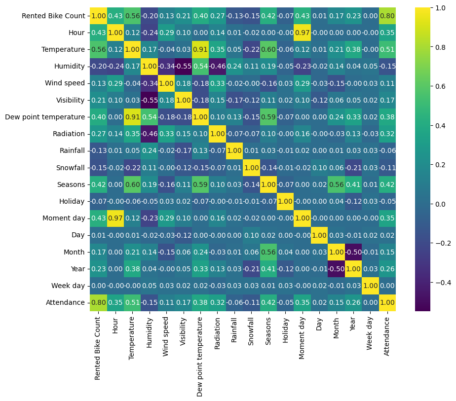

```python
# Correlation matrix
plt.figure(figsize=(10, 8))
correlation_matrix = df.corr()
sns.heatmap(correlation_matrix, annot=True, cmap='viridis', fmt=".2f")
plt.show()
```

```python
df['Week day'].unique()
```

```
array([0, 1, 2, 3, 4, 5, 6])
```

```python
location_per_day = df.groupby(['Week day'])['Rented Bike Count'].mean()
location_per_day.index = location_per_day.index.map(dic_week_day)

location_per_day.head()
```

```
Week day
Friday      776.416667
Saturday    727.602301
Sunday      637.413399
Monday      730.563301
Tuesday     745.309028
Name: Rented Bike Count, dtype: float64
```

> We observe a strong correlation between Dew point temperature and Temperature. Dew point temperature is a less meaningful variable than Temperature, so we delete it in order to avoid redundant variables.

> We also observe a correlation of 0 between the day of the week and the number of bikes rented. However, according to location_per_day, the number of bikes rented on Sundays is lower. That's why we decide to keep this column.

> Similarly, despite a very strong correlation between the hour and the time of day (an obvious strong correlation since one of the columns is created from the other), we will keep both initially and make a selection during the machine learning phase.

> We also see that meteorological characteristics do not seem to have a major importance in the number of bikes rented (low correlation). However, it is observed that the most influential factors are the temperature, the hour, the time of day, and the season.

> We see that the correlation between the number of bikes rented and attendance is very high, which is a good thing since we chose to make predictions on attendance rather than on the exact number of bikes rented, which could never be predicted precisely anyway.

```python
df = df.drop(columns='Dew point temperature')
df_gd = df_gd.drop(columns='Dew point temperature')
```

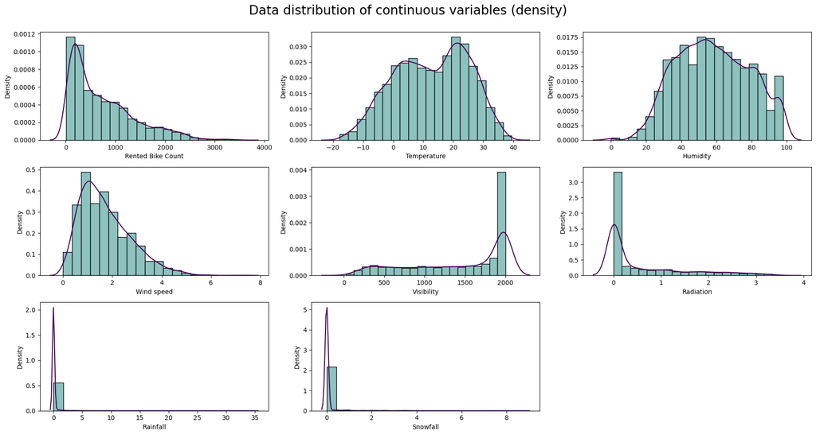

```python
columns = df[['Rented Bike Count', 'Temperature', 'Humidity', 'Wind speed', 'Visibility', 'Radiation', 'Rainfall', 'Snowfall']]

plt.figure(figsize=(18, 18))
for i, col in enumerate(columns):
    ax = plt.subplot(6, 3, i+1)
    plt.hist(df[col], bins=20, color='#8dc2bf', edgecolor='black', density=True)
    sns.kdeplot(df[col], color='#440154')
    plt.xlabel(f'{col}')
    plt.ylabel('Density')
plt.suptitle('Data distribution of continuous variables (density)',y=1,fontsize=20)
plt.tight_layout()
```

We display the density and distribution of each meteorological characteristic as well as that of our target variable. From this, we can conclude several things:

- Temperatures in Seoul range between -20°C and 40°C, with a majority of temperatures close to those in France, between -7°C and 30°C.
- The climate is relatively humid.
- Wind speed remains reasonable, not attributing any particular characteristics to the city of Seoul.
- There generally seems to be good visibility, although a small number of particular cases with lack of visibility should be considered.
- Radiation levels are also relatively low but, like visibility, can occasionally become more significant.
- Rainfall and snowfall remain low.

Thus, we can confirm what we deduced from the correlation matrix, namely that these factors do not add much in terms of particularities to the city of Seoul and people's habits regarding bike use.

Regarding our target, the number of bikes rented, we will conduct an additional study.

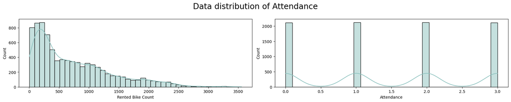

```python
# Bar Plot
columns_target = df[['Rented Bike Count', 'Attendance']]

plt.figure(figsize=(18, 18))
for i, col in enumerate(columns_target):
    ax = plt.subplot(6,2, i+1)
    sns.histplot(data=df, x=col, ax=ax, color='#8dc2bf',kde=True)
plt.suptitle('Data distribution of Attendance',y=1,fontsize=20)
plt.tight_layout()
```

Creating our attendance target based on percentiles allows us to have four classes that are evenly distributed, which is very important for the accuracy of our model.

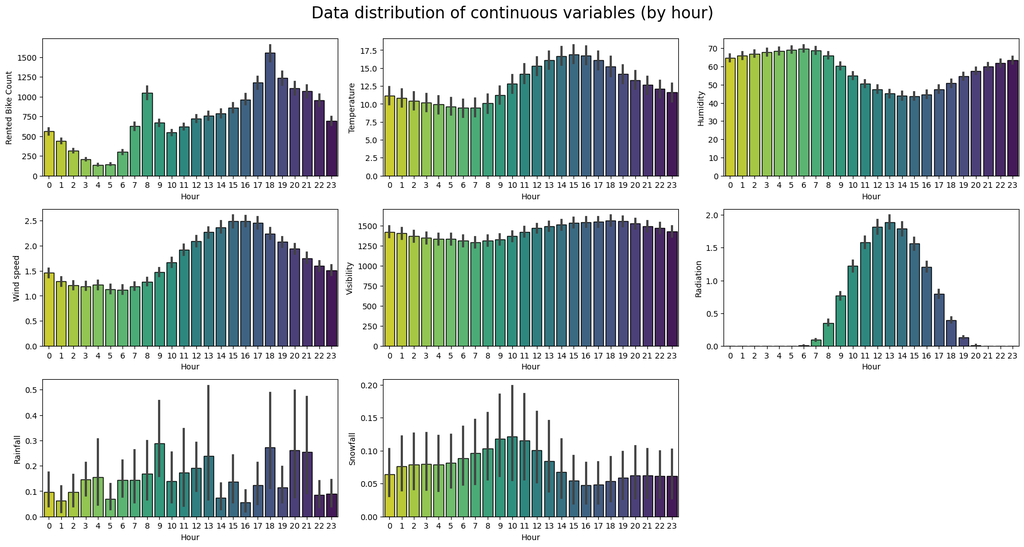

```python
# Bar Plot

plt.figure(figsize=(18, 18))
for i, col in enumerate(columns):
    ax = plt.subplot(6,3, i+1)
    sns.barplot(data=df,x='Hour', y=col, ax=ax,edgecolor="black",palette='viridis_r')
plt.suptitle('Data distribution of continuous variables (by hour)',y=1,fontsize=20)
plt.tight_layout()
```

Here, we display all our meteorological characteristics along with our target variable based on the time of day.

The distributions we obtain are logical with what we know: the temperature is higher between late morning and late afternoon, radiation is more significant during the day when the sun is out, and humidity is higher at night...

Now, moving on to our target, it appears that bikes are generally rented more in the afternoon and we observe peaks during the start and end of work hours. We will verify this with other graphs.

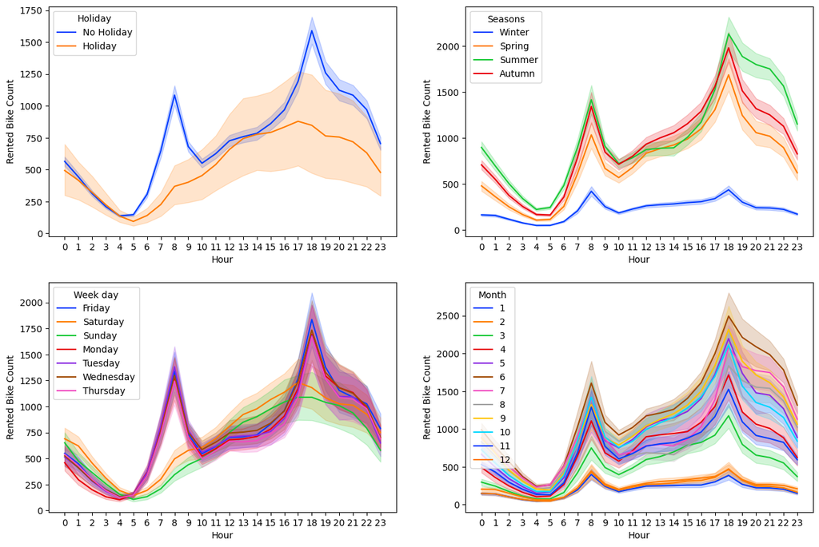

```python
fig, axes = plt.subplots(nrows=2, ncols=2, figsize=(15, 10))

axes[0][0].set_xticks(np.arange(df['Hour'].min(), df['Hour'].max() + 1, step=1))
sns.lineplot(x=df['Hour'], y=df['Rented Bike Count'], hue=df['Holiday'].map(dic_holiday), data=df, palette='bright', ax=axes[0][0])

axes[0][1].set_xticks(np.arange(df['Hour'].min(), df['Hour'].max() + 1, step=1))
sns.lineplot(x=df['Hour'], y=df['Rented Bike Count'], hue=df['Seasons'].map(dic_season), data=df, palette='bright', ax=axes[0][1])

axes[1][0].set_xticks(np.arange(df['Hour'].min(), df['Hour'].max() + 1, step=1))
sns.lineplot(x=df['Hour'], y=df['Rented Bike Count'], hue=df['Week day'].map(dic_week_day), data=df, palette='bright', ax=axes[1][0])

axes[1][1].set_xticks(np.arange(df['Hour'].min(), df['Hour'].max() + 1, step=1))
sns.lineplot(x=df['Hour'], y=df['Rented Bike Count'], hue=df['Month'], data=df, palette='bright', ax=axes[1][1])
```

The overall study of these four graphs allows us to validate our earlier hypothesis: during school periods, on weekdays, the number of rented bikes experiences a peak during the start and end of work hours (6 AM-9 AM and 5 PM-7 PM). We also notice that the number of rented bicycles increases in the evening (a time when people relax after work).

- 1st Graph \ We observe that the number of bikes rented is higher during school periods than during holidays. This leads us to hypothesize that in Seoul, biking is more a means of transportation than a leisure activity. We will delve a bit deeper into this hypothesis shortly, using a more significant graph.
- 2nd Graph\ Regarding the seasons, we notice that the only month that stands out is winter, with fewer bikes rented. However, the two peaks of the start and end of work hours remain visible.
- 3rd Graph\ This graph allows us to visualize that on weekends (days when people normally work less), the two peaks of the start and end of work hours are not visible. However, we observe that on weekends, bikes are more rented in the afternoon and evening. During the week, we clearly see our two peaks, and whether it's Monday or another day, the number of bikes rented follows the same curve.
- 4th Graph\ This graph is consistent with the one about the seasons.

```python
# Study of Holiday
mean_holiday=df.groupby(['Holiday'])['Rented Bike Count'].mean()
print(mean_holiday)
```

```
Holiday
0    739.284970
1    529.154412
Name: Rented Bike Count, dtype: float64
```

```
<function matplotlib.pyplot.show(close=None, block=None)>
```

[figure not shown]

```python
plt.figure(figsize=(6, 4))
plt.bar(['Holiday', 'No Holiday'], mean_holiday, color=['#440154', '#5ec962'])
plt.title('Mean count of Rented Bike during holidays and outside of holidays')
plt.ylabel('Count')
plt.show
```

We notice that bikes are rented more during school periods than during holiday periods. Thus, we can definitively confirm that the favorable period for bike rentals is the school period, when people are working.

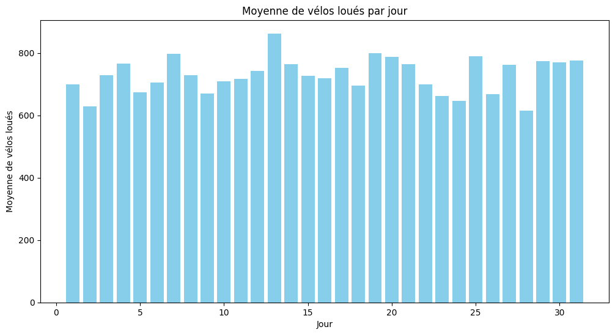

```python
rented_per_day = df.groupby('Day')['Rented Bike Count'].mean().reset_index()

plt.figure(figsize=(12, 6))
plt.bar(rented_per_day['Day'], rented_per_day['Rented Bike Count'], color='skyblue')

plt.title('Moyenne de vélos loués par jour')
plt.xlabel('Jour')
plt.ylabel('Moyenne de vélos loués')
plt.show()
```

We see that depending on the days of the month, the average number of bikes rented fluctuates between 600 and 850, to give a broad range. We tried to explain this variation, but the disparity between holidays, vacations, and weekends did not allow us to reach a conclusion. However, we will keep this column as it can provide important details and will enable us to predict attendance based on a date in the format %d%m.

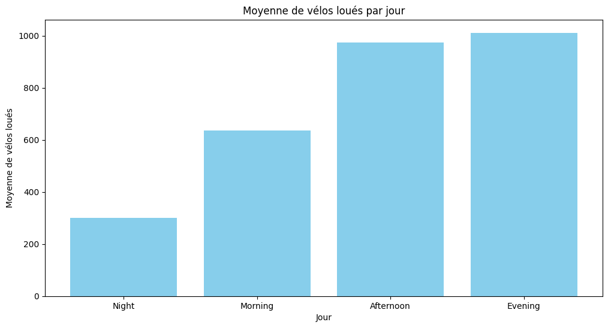

```python
rented_per_moment_day = df.groupby('Moment day')['Rented Bike Count'].mean().reset_index()

plt.figure(figsize=(12, 6))
plt.bar(rented_per_moment_day['Moment day'].map(dic_moment_day), rented_per_moment_day['Rented Bike Count'], color='skyblue')

plt.title('Moyenne de vélos loués par jour')
plt.xlabel('Jour')
plt.ylabel('Moyenne de vélos loués')
plt.show()
```

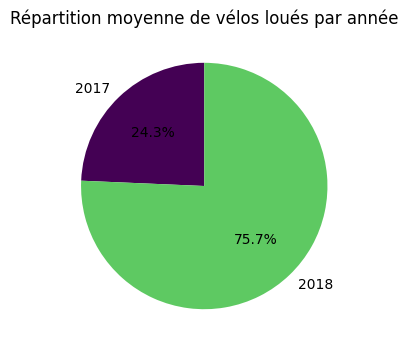

```python
rented_per_year = df.groupby('Year')['Rented Bike Count'].mean().reset_index()

plt.figure(figsize=(4, 4))
plt.pie(rented_per_year['Rented Bike Count'], labels=rented_per_year['Year'], autopct='%1.1f%%', startangle=90, colors=['#440154', '#5ec962'])

plt.title('Répartition moyenne de vélos loués par année')

plt.show()
```

We observe that the number of bikes rented has increased significantly between 2017 and 2018. After conducting some research, we learned that the bike-sharing service was introduced in Seoul in 2015. Between 2015 and 2016, the number of bikes increased from 9,468 to 14,088 and reached 20,000 in 2018 ([Les vélos publics dotés des TIC prennent Séoul d’assaut](https://french.korea.net/NewsFocus/Society/view?articleId=156697)). Thus, this infrastructure is continuously evolving in Seoul, and a forecast based on only two years will not allow us to account for changes over the years. Therefore, we will remove this column.

```python
df = df.drop(columns='Year')
df_gd = df_gd.drop(columns='Year')
```

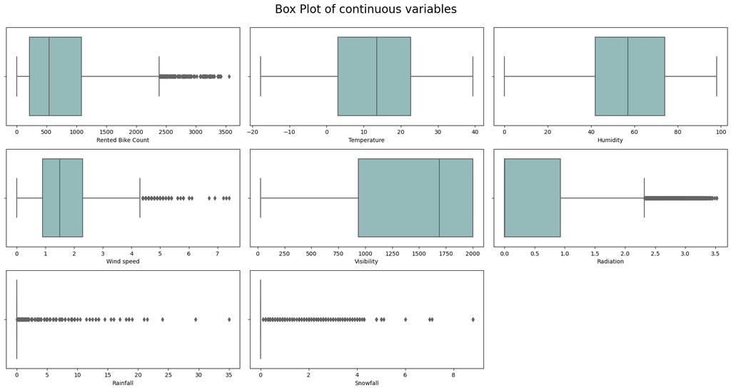

```python
# Box Plot


plt.figure(figsize=(18, 18))
for i, col in enumerate(columns):
    ax = plt.subplot(6,3, i+1)
    sns.boxplot(data=df, x=col, ax=ax,color='#8dc2bf')
plt.suptitle('Box Plot of continuous variables',y=1,fontsize=20)
plt.tight_layout()
```

```python
df.head()
```

|  | Rented Bike Count | Hour | Temperature | Humidity | Wind speed | Visibility | Radiation | Rainfall | Snowfall | Seasons | Holiday | Moment day | Day | Month | Week day | Attendance |
| --- | --- | --- | --- | --- | --- | --- | --- | --- | --- | --- | --- | --- | --- | --- | --- | --- |
| 0 | 254 | 0 | -5.2 | 37 | 2.2 | 2000 | 0.0 | 0.0 | 0.0 | 0 | 0 | 0 | 1 | 12 | 0 | 0 |
| 1 | 204 | 1 | -5.5 | 38 | 0.8 | 2000 | 0.0 | 0.0 | 0.0 | 0 | 0 | 0 | 1 | 12 | 0 | 1 |
| 2 | 173 | 2 | -6.0 | 39 | 1.0 | 2000 | 0.0 | 0.0 | 0.0 | 0 | 0 | 0 | 1 | 12 | 0 | 1 |
| 3 | 107 | 3 | -6.2 | 40 | 0.9 | 2000 | 0.0 | 0.0 | 0.0 | 0 | 0 | 0 | 1 | 12 | 0 | 1 |
| 4 | 78 | 4 | -6.0 | 36 | 2.3 | 2000 | 0.0 | 0.0 | 0.0 | 0 | 0 | 0 | 1 | 12 | 0 | 1 |

# MACHINE LEARNING

## **Modeling : The attendance is determined based on the percentiles**

```python
pip install scikit-learn-extra
```

### **CLUSTERING**

```python
# Import librairies
import scipy as sc
import sklearn_extra
from sklearn_extra.cluster import KMedoids
from sklearn.cluster import KMeans
from sklearn.cluster import DBSCAN
```

The ARI yields a score between -1 and 1. A score of 1 indicates a perfect agreement between the clusterings, 0 indicates a random clustering, and -1 indicates a perfect disagreement.

```python
import sys

def rand_index(ref, est):
  num = 0
  if len(ref) != len(est):
    print('Arrays must be of the same size')
    sys.exit(1)
  for k in range(len(ref)):
    for l in range(len(ref)-k-1):
      if (ref[k]==ref[k+l+1] and est[k]==est[k+l+1]) or (ref[k]!=ref[k+l+1] and est[k]!=est[k+l+1]):
        num += 1
  den = len(ref)*(len(ref)-1)/2
  return num/den
```

```python
# Hierarchical clustering function
def agglomerativeClustering(x, k):
  d = sc.spatial.distance.pdist(x)
  l = sc.cluster.hierarchy.linkage(d)
  return sc.cluster.hierarchy.fcluster(l, k, criterion='maxclust')
```

*With OrdinaEncoder*

```python
# Extraction of targets and data
targets = df['Attendance'].to_numpy()
data = df.drop(['Rented Bike Count','Attendance'], axis=1).to_numpy().astype(np.float64)
```

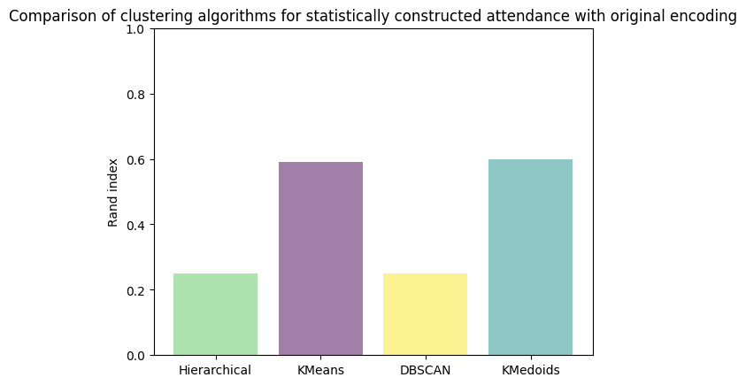

```python
# Comparison of several clustering algorithms
ri = np.zeros((4))
x=[0,1,2,3]

kmedoids = KMedoids(n_clusters=4, random_state=42)
kmeans = KMeans(n_clusters=4, random_state=42)
kmeans.fit(data)
ri[0] = rand_index(targets, agglomerativeClustering(data, 4))
ri[1] = rand_index(targets, kmeans.labels_ )
ri[2] = rand_index(targets, DBSCAN(eps=0.5, min_samples=5).fit(data).labels_)
ri[3] = rand_index(targets, kmedoids.fit_predict(data))

plt.title('Comparison of clustering algorithms for statistically constructed attendance with original encoding')
plt.bar(x, ri, alpha=0.5, ecolor='black', color=['#5ec962','#440154','#fde725','#21918c'])
plt.ylim(0,1)
plt.ylabel('Rand index')
plt.xticks(x, ['Hierarchical', 'KMeans', 'DBSCAN', 'KMedoids'])
plt.show()
```

*With get_dummies*

```python
targets_gd = df_gd['Attendance'].to_numpy()
data_gd = df_gd.drop(['Rented Bike Count','Attendance'], axis=1).to_numpy().astype(np.float64)
```

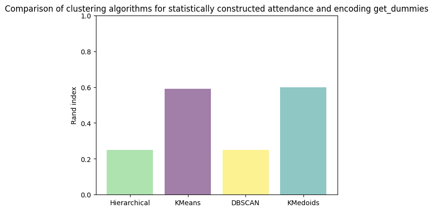

```python
# Comparison of several clustering algorithms
ri = np.zeros((4))
x=[0,1,2,3]

kmedoids = KMedoids(n_clusters=4, random_state=42)
kmeans = KMeans(n_clusters=4, random_state=42)
kmeans.fit(data_gd)
ri[0] = rand_index(targets_gd, agglomerativeClustering(data_gd, 4))
ri[1] = rand_index(targets_gd, kmeans.labels_ )
ri[2] = rand_index(targets_gd, DBSCAN(eps=0.5, min_samples=5).fit(data_gd).labels_)
ri[3] = rand_index(targets_gd, kmedoids.fit_predict(data_gd))

plt.title('Comparison of clustering algorithms for statistically constructed attendance and encoding get_dummies')
plt.bar(x, ri, alpha=0.5, ecolor='black', color=['#5ec962','#440154','#fde725','#21918c'])
plt.ylim(0,1)
plt.ylabel('Rand index')
plt.xticks(x, ['Hierarchical', 'KMeans', 'DBSCAN', 'KMedoids'])
plt.show()
```

Encoding does not influence the performance ofthe clustering.

### **DecisionTree and Naive Bayesian**

```python
# Data preprocessing for linear regression
from sklearn.preprocessing import StandardScaler

scaler = StandardScaler()
X = scaler.fit_transform(data)
Y = df.loc[:, 'Attendance']

X_gd = scaler.fit_transform(data_gd)
Y_gd = df_gd.loc[:, 'Attendance']
```

```python
# Splitting data into training and testing sets
from sklearn.model_selection import train_test_split

X_train, X_test, y_train, y_test = train_test_split(X, Y, test_size=0.2, random_state=20, stratify=Y)

X_train_gd, X_test_gd, y_train_gd, y_test_gd = train_test_split(X_gd, Y_gd, test_size=0.2, random_state=20, stratify=Y_gd)
```

#### Decision Tree

```python
from sklearn.tree import DecisionTreeClassifier
from sklearn.metrics import accuracy_score
from sklearn.metrics import confusion_matrix
from sklearn.metrics import classification_report
from sklearn.metrics import r2_score
from sklearn.metrics import mean_squared_error
from sklearn.model_selection import GridSearchCV
```

*With OrdinalEncoder*

Now let's try the Decision tree with both 'gini' and 'entropy'. We will run it 30 times to see what is the best max_depth for each algo

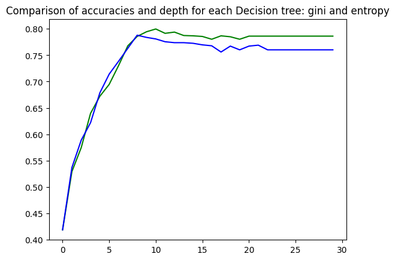

```python
# Plot to test the different depths of the tree
acc_entropy=[]
acc_gini=[]

for i in range(30):
  tree_entropy = DecisionTreeClassifier(max_depth=i+1, random_state = 42, criterion='entropy')
  tree_entropy.fit(X_train, y_train)
  y_pred_entropy = tree_entropy.predict(X_test)
  accuracy_entropy = accuracy_score(y_test, y_pred_entropy)
  acc_entropy.append(accuracy_entropy)

  tree_gini = DecisionTreeClassifier(max_depth=i+1, random_state = 42, criterion='gini')
  tree_gini.fit(X_train, y_train)
  y_pred_gini = tree_gini.predict(X_test)
  accuracy_gini = accuracy_score(y_test, y_pred_gini)
  acc_gini.append(accuracy_gini)

plt.title('Comparison of accuracies and depth for each Decision tree: gini and entropy')
plt.plot(range(30),acc_entropy,color='green')
plt.plot(range(30),acc_gini,color='blue')
```

```python
# Identifying the Best Depth for the Gini Tree
best_accuracy_g=max(acc_gini)
best_depth_g=acc_gini.index(best_accuracy_g)+1
print(f'Deciscion tree with gini maximzed depth: {best_depth_g} with accuracy {best_accuracy_g}')

best_accuracy_a=max(acc_entropy)
best_depth_a=acc_entropy.index(best_accuracy_a)+1
print(f'Deciscion tree with entropy maximzed depth: {best_depth_a} with accuracy {best_accuracy_a}')
```

```
Deciscion tree with gini maximzed depth: 9 with accuracy 0.7879503839338452
Deciscion tree with entropy maximzed depth: 11 with accuracy 0.7997637330183107
```

```python
# Apply the best depth on criterion 'gini'
tree_gini = DecisionTreeClassifier(max_depth=best_depth_g, random_state = 42, criterion='gini')
tree_gini.fit(X_train, y_train)
y_pred_gini = tree_gini.predict(X_test)
accuracy_gini = accuracy_score(y_test, y_pred_gini)
conf_matrix_g = confusion_matrix(y_test, y_pred_gini)
classification_rep_g = classification_report(y_test, y_pred_gini)
print("The precision of the tree with gini is: ", accuracy_gini)
print(f"Confusion Matrix:\n{conf_matrix_g}")
print(f"Classification Report:\n{classification_rep_g}")
```

```
The precision of the tree with gini is:  0.7879503839338452
Confusion Matrix:
[[332  46  39   5]
 [ 73 346   4   2]
 [ 68   8 286  61]
 [  4   0  49 370]]
Classification Report:
              precision    recall  f1-score   support

           0       0.70      0.79      0.74       422
           1       0.86      0.81      0.84       425
           2       0.76      0.68      0.71       423
           3       0.84      0.87      0.86       423

    accuracy                           0.79      1693
   macro avg       0.79      0.79      0.79      1693
weighted avg       0.79      0.79      0.79      1693
```

```python
# Apply the best depth Entropy criterion
tree_entropy = DecisionTreeClassifier(max_depth=best_depth_a, random_state = 42, criterion='entropy')
tree_entropy.fit(X_train, y_train)
y_pred_entropy = tree_entropy.predict(X_test)
accuracy_entropy = accuracy_score(y_test, y_pred_entropy)
conf_matrix_e = confusion_matrix(y_test, y_pred_entropy)
classification_rep_e = classification_report(y_test, y_pred_entropy)
print("The precision of the tree with entropy is: ", accuracy_entropy)
print(f"Confusion Matrix:\n{conf_matrix_e}")
print(f"Classification Report:\n{classification_rep_e}")
```

```
The precision of the tree with entropy is:  0.7997637330183107
Confusion Matrix:
[[333  44  36   9]
 [ 64 359   2   0]
 [ 59  11 287  66]
 [  4   1  43 375]]
Classification Report:
              precision    recall  f1-score   support

           0       0.72      0.79      0.76       422
           1       0.87      0.84      0.85       425
           2       0.78      0.68      0.73       423
           3       0.83      0.89      0.86       423

    accuracy                           0.80      1693
   macro avg       0.80      0.80      0.80      1693
weighted avg       0.80      0.80      0.80      1693
```

```python
model_comparison_originalE={}
```

```python
model_comparison_originalE['Decision Tree Regression']=[r2_score(y_test, y_pred_entropy),mean_squared_error(y_test, y_pred_entropy),(accuracy_entropy)]
```

*With get_dummies*

```python
from sklearn.tree import DecisionTreeClassifier
from sklearn.metrics import accuracy_score
from sklearn.metrics import confusion_matrix
from sklearn.metrics import classification_report
```

```python
model_comparison_getdum={}
```

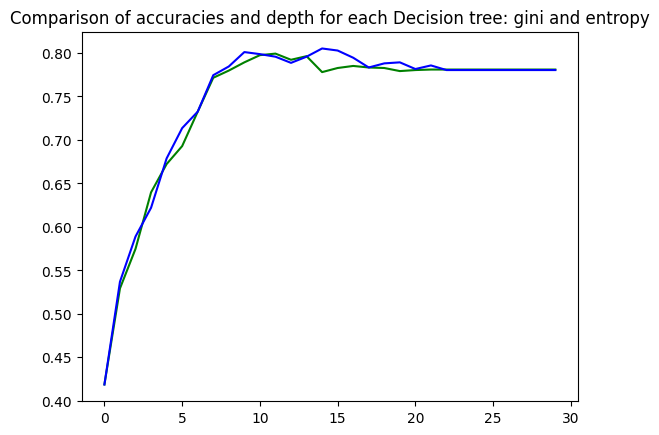

```python
# Plot to test the different depths of the tree
acc_entropy=[]
acc_gini=[]

for i in range(30):
  tree_entropy = DecisionTreeClassifier(max_depth=i+1, criterion='entropy',random_state=42)
  tree_entropy.fit(X_train_gd, y_train_gd)
  y_pred_entropy = tree_entropy.predict(X_test_gd)
  accuracy_entropy = accuracy_score(y_test_gd, y_pred_entropy)
  acc_entropy.append(accuracy_entropy)

  tree_gini = DecisionTreeClassifier(max_depth=i+1, criterion='gini',random_state=42)
  tree_gini.fit(X_train_gd, y_train_gd)
  y_pred_gini = tree_gini.predict(X_test_gd)
  accuracy_gini = accuracy_score(y_test_gd, y_pred_gini)
  acc_gini.append(accuracy_gini)

plt.title('Comparison of accuracies and depth for each Decision tree: gini and entropy')
plt.plot(range(30),acc_entropy,color='green')
plt.plot(range(30),acc_gini,color='blue')
```

```python
# Identifying the Best Depth for the Gini Tree
best_accuracy_g=max(acc_gini)
best_depth_g=acc_gini.index(best_accuracy_g)+1
print(f'Deciscion tree with gini maximzed depth: {best_depth_g} with accuracy {best_accuracy_g}')

best_accuracy_a=max(acc_entropy)
best_depth_a=acc_entropy.index(best_accuracy_a)+1
print(f'Deciscion tree with entropy maximzed depth: {best_depth_a} with accuracy {best_accuracy_a}')
```

```
Deciscion tree with gini maximzed depth: 15 with accuracy 0.8050797401063201
Deciscion tree with entropy maximzed depth: 12 with accuracy 0.7991730655640874
```

```python
# Training and evaluation of a decision tree with the Gini criterion
tree_gini = DecisionTreeClassifier(max_depth=best_depth_g, random_state = 42, criterion='gini')
tree_gini.fit(X_train_gd, y_train_gd)
y_pred_gini = tree_gini.predict(X_test_gd)
accuracy_gini = accuracy_score(y_test_gd, y_pred_gini)
conf_matrix_g = confusion_matrix(y_test_gd, y_pred_gini)
classification_rep_g = classification_report(y_test_gd, y_pred_gini)
print("The precision of the tree with gini is: ", accuracy_gini)
print(f"Confusion Matrix:\n{conf_matrix_g}")
print(f"Classification Report:\n{classification_rep_g}")
```

```
The precision of the tree with gini is:  0.8050797401063201
Confusion Matrix:
[[329  49  38   6]
 [ 51 368   5   1]
 [ 47   7 315  54]
 [  4   0  68 351]]
Classification Report:
              precision    recall  f1-score   support

           0       0.76      0.78      0.77       422
           1       0.87      0.87      0.87       425
           2       0.74      0.74      0.74       423
           3       0.85      0.83      0.84       423

    accuracy                           0.81      1693
   macro avg       0.81      0.80      0.81      1693
weighted avg       0.81      0.81      0.81      1693
```

```python
# Training and evaluation of a decision tree with the Entropy criterion
tree_entropy = DecisionTreeClassifier(max_depth=best_depth_a, random_state = 42, criterion='entropy')
tree_entropy.fit(X_train_gd, y_train_gd)
y_pred_entropy = tree_entropy.predict(X_test_gd)
accuracy_entropy = accuracy_score(y_test_gd, y_pred_entropy)
conf_matrix_e = confusion_matrix(y_test_gd, y_pred_entropy)
classification_rep_e = classification_report(y_test_gd, y_pred_entropy)
print("The precision of the tree with entropy is: ", accuracy_entropy)
print(f"Confusion Matrix:\n{conf_matrix_e}")
print(f"Classification Report:\n{classification_rep_e}")
```

```
The precision of the tree with entropy is:  0.7991730655640874
Confusion Matrix:
[[344  42  29   7]
 [ 56 365   4   0]
 [ 69   7 278  69]
 [  3   1  53 366]]
Classification Report:
              precision    recall  f1-score   support

           0       0.73      0.82      0.77       422
           1       0.88      0.86      0.87       425
           2       0.76      0.66      0.71       423
           3       0.83      0.87      0.85       423

    accuracy                           0.80      1693
   macro avg       0.80      0.80      0.80      1693
weighted avg       0.80      0.80      0.80      1693
```

```python
model_comparison_getdum['Decision Tree Regression']=[r2_score(y_test, y_pred_entropy),mean_squared_error(y_test, y_pred_entropy),(accuracy_gini)]
```

We observe that encoding with get_dummies leads to higher accuracy for the Decision Tree with Gini, whereas both encodings yield very similar results for the Decision Tree with Entropy.

The highest accuracy we achieve is with the Decision Tree using Gini with get_dummies encoding, and it is 80%

#### Naiive Bayesian

```python
# Data normalization with different scalers
from sklearn.preprocessing import MinMaxScaler

scaler_STD = StandardScaler()
scaler_Norm = MinMaxScaler()
X_train_STD = scaler_STD.fit_transform(X_train)
X_test_STD = scaler_STD.fit_transform(X_test)
X_train_STD_gd = scaler_STD.fit_transform(X_train_gd)
X_test_STD_gd = scaler_STD.fit_transform(X_test_gd)
```

*With OrdinalEncoder*

```python
# Naive Bayesian classification with evaluation
from sklearn.naive_bayes import GaussianNB
from sklearn.metrics import classification_report, confusion_matrix

model = GaussianNB()
model.fit(X_train_STD, y_train)
y_pred = model.predict(X_test_STD)

accuracy = accuracy_score(y_test, y_pred)
conf_matrix = confusion_matrix(y_test, y_pred)
classification_rep = classification_report(y_test, y_pred)

print(f"Accuracy: {accuracy}")
print(f"Confusion Matrix:\n{conf_matrix}")
print(f"Classification Report:\n{classification_rep}")
```

```
Accuracy: 0.46721795629060836
Confusion Matrix:
[[210  31  96  85]
 [242 110  62  11]
 [ 37   9  64 313]
 [  4   1  11 407]]
Classification Report:
              precision    recall  f1-score   support

           0       0.43      0.50      0.46       422
           1       0.73      0.26      0.38       425
           2       0.27      0.15      0.20       423
           3       0.50      0.96      0.66       423

    accuracy                           0.47      1693
   macro avg       0.48      0.47      0.42      1693
weighted avg       0.48      0.47      0.42      1693
```

```python
# Grid Search for Naive Bayesian
param_grid_nb = {
    'var_smoothing': [1e-9, 1e-8, 1e-7, 1e-6, 1e-5]
}

nb_model = GaussianNB()
grid_search_nb = GridSearchCV(nb_model, param_grid_nb, cv=5, scoring='accuracy')
grid_search_nb.fit(X_train_STD, y_train)

best_params_nb = grid_search_nb.best_params_
best_accuracy_nb = grid_search_nb.best_score_

final_nb_model = grid_search_nb.best_estimator_
final_nb_model.fit(X_train, y_train)
y_pred = final_nb_model.predict(X_test)
model_comparison_originalE['Naive Bayesian Regression']=[r2_score(y_test,y_pred),mean_squared_error(y_test,y_pred),(best_accuracy_nb)]
```

*With get_dummies*

```python
# Naive Bayesian classification with evaluation
from sklearn.naive_bayes import GaussianNB
from sklearn.metrics import classification_report, confusion_matrix

model = GaussianNB()
model.fit(X_train_STD_gd, y_train_gd)
y_pred = model.predict(X_test_STD_gd)

accuracy = accuracy_score(y_test_gd, y_pred)
conf_matrix = confusion_matrix(y_test_gd, y_pred)
classification_rep = classification_report(y_test_gd, y_pred)

print(f"Accuracy: {accuracy}")
print(f"Confusion Matrix:\n{conf_matrix}")
print(f"Classification Report:\n{classification_rep}")
```

```
Accuracy: 0.4388659184878913
Confusion Matrix:
[[206  42 174   0]
 [182 166  77   0]
 [ 40  12 371   0]
 [  4   4 415   0]]
Classification Report:
              precision    recall  f1-score   support

           0       0.48      0.49      0.48       422
           1       0.74      0.39      0.51       425
           2       0.36      0.88      0.51       423
           3       0.00      0.00      0.00       423

    accuracy                           0.44      1693
   macro avg       0.39      0.44      0.38      1693
weighted avg       0.39      0.44      0.38      1693
```

```python
# Grid Search for Naive Bayesian
param_grid_nb = {
    'var_smoothing': [1e-9, 1e-8, 1e-7, 1e-6, 1e-5]
}

nb_model = GaussianNB()
grid_search_nb = GridSearchCV(nb_model, param_grid_nb, cv=5, scoring='accuracy')
grid_search_nb.fit(X_train_STD, y_train)

best_params_nb = grid_search_nb.best_params_
best_accuracy_nb = grid_search_nb.best_score_

final_nb_model = grid_search_nb.best_estimator_
final_nb_model.fit(X_train, y_train)
y_pred = final_nb_model.predict(X_test)
model_comparison_getdum['Naive Bayesian Regression']=[r2_score(y_test,y_pred),mean_squared_error(y_test,y_pred),(best_accuracy_nb)]
```

The accuracy is not optimal both with the 2 kinds of encoding. Then, for the staticcally built 'attendance', this is not an optimal algo.

#### Random Forest

*With OrdinalEncoder*

```python
# Building a Pipeline with PCA and RandomForest Classifier
from sklearn.decomposition import PCA
from sklearn.ensemble import RandomForestClassifier
from sklearn.pipeline import make_pipeline

ML_pipeline = make_pipeline(StandardScaler(), PCA(n_components=2), RandomForestClassifier(criterion='entropy', n_estimators=200, max_depth=20, min_samples_split=2, random_state=42))
ML_pipeline.fit(X_train, y_train)
y_pred = ML_pipeline.predict(X_test)
test_acc = ML_pipeline.score(X_test, y_test)
conf_matrix = confusion_matrix(y_test, y_pred)
classification_rep = classification_report(y_test, y_pred)
print(f'Test accuracy: {test_acc:.3f}')
print(f"Confusion Matrix:\n{conf_matrix}")
print(f"Classification Report:\n{classification_rep}")
```

```
Test accuracy: 0.527
Confusion Matrix:
[[202 139  61  20]
 [114 272  30   9]
 [ 93  48 130 152]
 [ 25   8 101 289]]
Classification Report:
              precision    recall  f1-score   support

           0       0.47      0.48      0.47       422
           1       0.58      0.64      0.61       425
           2       0.40      0.31      0.35       423
           3       0.61      0.68      0.65       423

    accuracy                           0.53      1693
   macro avg       0.52      0.53      0.52      1693
weighted avg       0.52      0.53      0.52      1693
```

```python
# Finding the best hyperparameters for the RandomForest model
from sklearn.model_selection import GridSearchCV

param_grid = {
    'randomforestclassifier__n_estimators': [50,100, 200],
    'randomforestclassifier__max_depth': [5,10, 15],
    'randomforestclassifier__min_samples_split': [2,5,10]
}

grid_search = GridSearchCV(estimator=ML_pipeline, param_grid=param_grid, cv=5, verbose=1, n_jobs=-1)
grid_search.fit(X_train, y_train)
best_params = grid_search.best_params_
print("Best hyperparameters: ", best_params)
best_score = grid_search.best_score_
print("Best score: ", best_score)
best_model = grid_search.best_estimator_
y_pred = best_model.predict(X_test)
```

```
Fitting 5 folds for each of 27 candidates, totalling 135 fits
Best hyperparameters:  {'randomforestclassifier__max_depth': 5, 'randomforestclassifier__min_samples_split': 2, 'randomforestclassifier__n_estimators': 200}
Best score:  0.5781133391836134
```

```python
model_comparison_originalE['Random Forest']=[r2_score(y_test,y_pred),mean_squared_error(y_test,y_pred),(best_score)]
```

*With get_dummies*

```python
# Building a Pipeline with PCA and RandomForest Classifier
from sklearn.decomposition import PCA
from sklearn.ensemble import RandomForestClassifier
from sklearn.pipeline import make_pipeline

ML_pipeline = make_pipeline(StandardScaler(), PCA(n_components=2), RandomForestClassifier(criterion='entropy', n_estimators=200, max_depth=20, min_samples_split=2, random_state=42))
ML_pipeline.fit(X_train_gd, y_train_gd)
y_pred = ML_pipeline.predict(X_test_gd)
test_acc = ML_pipeline.score(X_test_gd, y_test_gd)
conf_matrix = confusion_matrix(y_test_gd, y_pred)
classification_rep = classification_report(y_test_gd, y_pred)
print(f'Test accuracy: {test_acc:.3f}')
print(f"Confusion Matrix:\n{conf_matrix}")
print(f"Classification Report:\n{classification_rep}")
```

```
Test accuracy: 0.580
Confusion Matrix:
[[207 113  77  25]
 [102 275  31  17]
 [ 77  34 199 113]
 [ 17   7  98 301]]
Classification Report:
              precision    recall  f1-score   support

           0       0.51      0.49      0.50       422
           1       0.64      0.65      0.64       425
           2       0.49      0.47      0.48       423
           3       0.66      0.71      0.68       423

    accuracy                           0.58      1693
   macro avg       0.58      0.58      0.58      1693
weighted avg       0.58      0.58      0.58      1693
```

```python
# Finding the best hyperparameters for the RandomForest model
from sklearn.model_selection import GridSearchCV

param_grid = {
    'randomforestclassifier__n_estimators': [50,100, 200],
    'randomforestclassifier__max_depth': [5,10, 15],
    'randomforestclassifier__min_samples_split': [2,5,10]
}

grid_search = GridSearchCV(estimator=ML_pipeline, param_grid=param_grid, cv=5, verbose=1, n_jobs=-1)
grid_search.fit(X_train, y_train)
best_params = grid_search.best_params_
print("Best hyperparameters: ", best_params)
best_score = grid_search.best_score_
print("Best score: ", best_score)
best_model = grid_search.best_estimator_
y_pred = best_model.predict(X_test)
```

```
Fitting 5 folds for each of 27 candidates, totalling 135 fits
Best hyperparameters:  {'randomforestclassifier__max_depth': 5, 'randomforestclassifier__min_samples_split': 2, 'randomforestclassifier__n_estimators': 200}
Best score:  0.5779656286961687
```

```python
model_comparison_getdum['Random Forest']=[r2_score(y_test,y_pred),mean_squared_error(y_test,y_pred),(best_score)]
```

Lets conclude with comparison of each algorithm with the 2 different encodings

*For orginal encoding*

```python
Model_com_df_O=pd.DataFrame(model_comparison_originalE).T
Model_com_df_O.columns=['R-Square','MSE','Accuracy']
Model_com_df_O=Model_com_df_O.sort_values(by='Accuracy',ascending=False)
Model_com_df_O.style.format("{:.2%}").background_gradient(cmap='viridis')
```

|  | R-Square | MSE | Accuracy |
| --- | --- | --- | --- |
| Decision Tree Regression | 65.41% | 43.18% | 79.98% |
| Random Forest | 22.11% | 97.22% | 57.81% |
| Naive Bayesian Regression | 0.86% | 123.74% | 45.55% |

*For get_dummies*

```python
Model_com_df_G=pd.DataFrame(model_comparison_getdum).T
Model_com_df_G.columns=['R-Square','MSE','Accuracy']
Model_com_df_G=Model_com_df_G.sort_values(by='Accuracy',ascending=False)
Model_com_df_G.style.format("{:.2%}").background_gradient(cmap='viridis')
```

|  | R-Square | MSE | Accuracy |
| --- | --- | --- | --- |
| Decision Tree Regression | 66.07% | 42.35% | 80.51% |
| Random Forest | 22.30% | 96.99% | 57.80% |
| Naive Bayesian Regression | 0.86% | 123.74% | 45.55% |

We can say that Get_dummies is a better encoding then for the rest of the ML we will use this type of encoding.

## **Modeling : The attendance is determined in a BINARY way.**

```python
df_gd['Attendance'].unique()
```

```
array([0, 1, 2, 3])
```

In the second step, we will determine attendance in a binary manner.

Thus, we will define crowds as follows:

- [0;1] = low attendance
- [2;3] = high attendance

```python
# We add a column for the attendance binary
def attendance(rented):
  if 0<=rented<=1:
    return 0
  if 2<=rented<=3:
    return 1

df = df_gd.copy()
df['Attendance']= df_gd['Attendance'].apply(lambda x : attendance(x))

df.head(5)
```

|  | Rented Bike Count | Hour | Temperature | Humidity | Wind speed | Visibility | Radiation | Rainfall | Snowfall | Day | ... | Moment day_Morning | Moment day_Night | Week day_Friday | Week day_Monday | Week day_Saturday | Week day_Sunday | Week day_Thursday | Week day_Tuesday | Week day_Wednesday | Holiday |
| --- | --- | --- | --- | --- | --- | --- | --- | --- | --- | --- | --- | --- | --- | --- | --- | --- | --- | --- | --- | --- | --- |
| 0 | 254 | 0 | -5.2 | 37 | 2.2 | 2000 | 0.0 | 0.0 | 0.0 | 1 | ... | 0 | 1 | 1 | 0 | 0 | 0 | 0 | 0 | 0 | 0 |
| 1 | 204 | 1 | -5.5 | 38 | 0.8 | 2000 | 0.0 | 0.0 | 0.0 | 1 | ... | 0 | 1 | 1 | 0 | 0 | 0 | 0 | 0 | 0 | 0 |
| 2 | 173 | 2 | -6.0 | 39 | 1.0 | 2000 | 0.0 | 0.0 | 0.0 | 1 | ... | 0 | 1 | 1 | 0 | 0 | 0 | 0 | 0 | 0 | 0 |
| 3 | 107 | 3 | -6.2 | 40 | 0.9 | 2000 | 0.0 | 0.0 | 0.0 | 1 | ... | 0 | 1 | 1 | 0 | 0 | 0 | 0 | 0 | 0 | 0 |
| 4 | 78 | 4 | -6.0 | 36 | 2.3 | 2000 | 0.0 | 0.0 | 0.0 | 1 | ... | 0 | 1 | 1 | 0 | 0 | 0 | 0 | 0 | 0 | 0 |

5 rows × 28 columns

```python
dic_attendance_binary = dic(['Low attendance', 'High attendance'])
print(dic_attendance_binary)
```

```
{0: 'Low attendance', 1: 'High attendance'}
```

```python
df['Attendance'].unique()
```

```
array([0, 1])
```

### **CLUSTERING**

```python
# Extraction of targets and data
targets = df['Attendance'].to_numpy()
data = df.drop(['Rented Bike Count','Attendance'], axis=1).to_numpy().astype(np.float64)
```

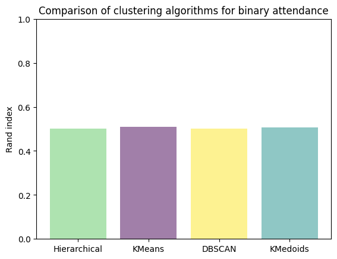

```python
# Comparison of several clustering algorithms
ri = np.zeros((4))
x=[0,1,2,3]

kmedoids = KMedoids(n_clusters=2, random_state=42)
kmeans = KMeans(n_clusters=2, random_state=42)
kmeans.fit(data)
ri[0] = rand_index(targets, agglomerativeClustering(data, 2))
ri[1] = rand_index(targets, kmeans.labels_ )
ri[2] = rand_index(targets, DBSCAN(eps=0.5, min_samples=5).fit(data).labels_)
ri[3] = rand_index(targets, kmedoids.fit_predict(data))
plt.title('Comparison of clustering algorithms for binary attendance')
plt.bar(x, ri, alpha=0.5, ecolor='black', color=['#5ec962','#440154','#fde725','#21918c'])
plt.ylim(0,1)
plt.ylabel('Rand index')
plt.xticks(x, ['Hierarchical', 'KMeans', 'DBSCAN', 'KMedoids'])
plt.show()
```

The clustering method performs less well with binary input. We achieve a performance of approximately 50% for each of the clustering techniques, which is relatively low compared to what we obtained previously.

### **DecisionTree (entropy and gini) and Naive Bayesian**

```python
model_comparison={}
```

```python
scaler = StandardScaler()
X = scaler.fit_transform(data)
Y = df.loc[:, 'Attendance']
```

```python
X_train, X_test, y_train, y_test = train_test_split(X, Y, test_size=0.2, random_state=20, stratify=Y)
```

#### Decision Tree

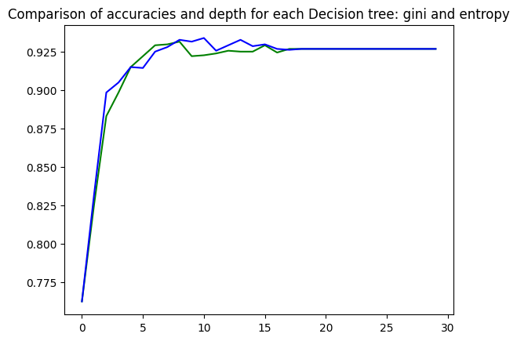

```python
# Plot to test the different depths of the tree
acc_entropy=[]
acc_gini=[]

for i in range(30):
  tree_entropy = DecisionTreeClassifier(max_depth=i+1, random_state = 42, criterion='entropy')
  tree_entropy.fit(X_train, y_train)
  y_pred_entropy = tree_entropy.predict(X_test)
  accuracy_entropy = accuracy_score(y_test, y_pred_entropy)
  acc_entropy.append(accuracy_entropy)

  tree_gini = DecisionTreeClassifier(max_depth=i+1, random_state = 42, criterion='gini')
  tree_gini.fit(X_train, y_train)
  y_pred_gini = tree_gini.predict(X_test)
  accuracy_gini = accuracy_score(y_test, y_pred_gini)
  acc_gini.append(accuracy_gini)

plt.title('Comparison of accuracies and depth for each Decision tree: gini and entropy')
plt.plot(range(30),acc_entropy,color='green')
plt.plot(range(30),acc_gini,color='blue')
```

```python
# Identifying the Best Depth for the Gini Tree
best_accuracy_g=max(acc_gini)
best_depth_g=acc_gini.index(best_accuracy_g)+1
print(f'Deciscion tree with gini maximzed depth: {best_depth_g} with accuracy {best_accuracy_g}')

best_accuracy_a=max(acc_entropy)
best_depth_a=acc_entropy.index(best_accuracy_a)+1
print(f'Deciscion tree with entropy maximzed depth: {best_depth_a} with accuracy {best_accuracy_a}')
```

```
Deciscion tree with gini maximzed depth: 11 with accuracy 0.9338452451269935
Deciscion tree with entropy maximzed depth: 9 with accuracy 0.9314825753101004
```

```python
# Training and evaluation of a decision tree with the Gini criterion
tree_gini_BS = DecisionTreeClassifier(max_depth=best_depth_g, random_state = 42, criterion='gini')
tree_gini_BS_fit = tree_gini_BS.fit(X_train, y_train)
tree_gini_BS.fit(X_train, y_train)
y_pred_gini = tree_gini_BS.predict(X_test)
accuracy_gini = accuracy_score(y_test, y_pred_gini)
conf_matrix_g = confusion_matrix(y_test, y_pred_gini)
classification_rep_g = classification_report(y_test, y_pred_gini)
print("The precision of the tree with gini is: ", accuracy_gini)
print(f"Confusion Matrix:\n{conf_matrix_g}")
print(f"Classification Report:\n{classification_rep_g}")
```

```
The precision of the tree with gini is:  0.9338452451269935
Confusion Matrix:
[[777  70]
 [ 42 804]]
Classification Report:
              precision    recall  f1-score   support

           0       0.95      0.92      0.93       847
           1       0.92      0.95      0.93       846

    accuracy                           0.93      1693
   macro avg       0.93      0.93      0.93      1693
weighted avg       0.93      0.93      0.93      1693
```

On verra en conclusion que ce modèle est le meilleur. C'est donc lui que nous allons utilisé pour l'API. On le télécharge donc en .pkl. Cependant, nous n'avons pas eu le temps de finir l'API, préférant nous concentrer sur l'efficacité de notre machine learning. En effet, elle semble tout le temps prédire 0 (c'est-à-dire une faible affluence) quelques soient les caractéristiques d'entrée. Nous avons quand même laisser une trace de notre travail.

```python
import pickle
# Remplacez 'votre_modele' par votre modèle
with open('model.pkl', 'wb') as file:
    pickle.dump(tree_gini_BS_fit, file)
```

```python
def Attendance(model, Hour, Temperature, Humidity, Wind_speed, Visibility, Radiation, Rainfall, Snowfall, Day, Month, Week_day_Friday, Week_day_Monday, Week_day_Saturday, Week_day_Sunday, Week_day_Thursday, Week_day_Tuesday, Week_day_Wednesday, Holiday):
    def seasons(M):
      if M >= 1 & M < 3 :
         Seasons_Autumn = 0
         Seasons_Spring = 0
         Seasons_Summer = 0
         Seasons_Winter = 1
         return Seasons_Autumn, Seasons_Spring, Seasons_Summer, Seasons_Winter
      if M >= 3 & M < 6 :
         Seasons_Autumn = 0
         Seasons_Spring = 1
         Seasons_Summer = 0
         Seasons_Winter = 0
         return Seasons_Autumn, Seasons_Spring, Seasons_Summer, Seasons_Winter
      if M >= 6 & M < 9 :
         Seasons_Autumn = 0
         Seasons_Spring = 0
         Seasons_Summer = 1
         Seasons_Winter = 0
         return Seasons_Autumn, Seasons_Spring, Seasons_Summer, Seasons_Winter
      if M >= 9 & M <= 12 :
         Seasons_Autumn = 1
         Seasons_Spring = 0
         Seasons_Summer = 0
         Seasons_Winter = 0
         return Seasons_Autumn, Seasons_Spring, Seasons_Summer, Seasons_Winter

    def moment_day(hour):
        if 0<=hour<6:
          Moment_day_Afternoon = 0
          Moment_day_Evening = 0
          Moment_day_Morning = 0
          Moment_day_Night = 1
          return Moment_day_Afternoon, Moment_day_Evening, Moment_day_Morning, Moment_day_Night
        if 6<=hour<12:
          Moment_day_Afternoon = 0
          Moment_day_Evening = 0
          Moment_day_Morning = 1
          Moment_day_Night = 0
          return Moment_day_Afternoon, Moment_day_Evening, Moment_day_Morning, Moment_day_Night
        if 12<=hour<=18:
          Moment_day_Afternoon = 1
          Moment_day_Evening = 0
          Moment_day_Morning = 0
          Moment_day_Night = 0
          return Moment_day_Afternoon, Moment_day_Evening, Moment_day_Morning, Moment_day_Night
        if 18<hour<=23:
          Moment_day_Afternoon = 0
          Moment_day_Evening = 1
          Moment_day_Morning = 0
          Moment_day_Night = 0
          return Moment_day_Afternoon, Moment_day_Evening, Moment_day_Morning, Moment_day_Night


    Seasons_Autumn, Seasons_Spring, Seasons_Summer,Seasons_Winter = seasons(Month)
    Moment_day_Afternoon, Moment_day_Evening, Moment_day_Morning, Moment_day_Night = moment_day(Hour)

    x = np.array([Hour, Temperature, Humidity, Wind_speed, Visibility, Radiation, Rainfall, Snowfall, Day, Month, Seasons_Autumn, Seasons_Spring, Seasons_Summer,Seasons_Winter, Moment_day_Afternoon, Moment_day_Evening, Moment_day_Morning, Moment_day_Night, Week_day_Friday, Week_day_Monday, Week_day_Saturday, Week_day_Sunday, Week_day_Thursday, Week_day_Tuesday, Week_day_Wednesday, Holiday]).reshape(1, -1)
    model.fit(X_train, y_train)
    prediction = model.predict(x)
    probability = model.predict_proba(x)
    formatted_probabilities = [[round(prob, 2) for prob in class_probs] for class_probs in probability]
    print("Prediction:", prediction)
    print("Probabilities:", probability)

Attendance(tree_gini_BS, 14, 15, 37, 2.2, 2000, 0.0, 0.0, 0.0, 11, 11, 0, 1, 0, 0, 0, 0, 0, 1)
```

```
Prediction: [0]
Probabilities: [[1. 0.]]
```

```python
tree_entropy = DecisionTreeClassifier(max_depth=best_depth_a, random_state = 42, criterion='entropy')
tree_entropy.fit(X_train, y_train)
y_pred_entropy = tree_entropy.predict(X_test)
accuracy_entropy = accuracy_score(y_test, y_pred_entropy)
conf_matrix_e = confusion_matrix(y_test, y_pred_entropy)
classification_rep_e = classification_report(y_test, y_pred_entropy)
print("The precision of the tree with entropy is: ", accuracy_entropy)
print(f"Confusion Matrix:\n{conf_matrix_e}")
print(f"Classification Report:\n{classification_rep_e}")
```

```
The precision of the tree with entropy is:  0.9314825753101004
Confusion Matrix:
[[778  69]
 [ 47 799]]
Classification Report:
              precision    recall  f1-score   support

           0       0.94      0.92      0.93       847
           1       0.92      0.94      0.93       846

    accuracy                           0.93      1693
   macro avg       0.93      0.93      0.93      1693
weighted avg       0.93      0.93      0.93      1693
```

```python
model_comparison['DecisionTree']=[r2_score(y_test,y_pred_gini),mean_squared_error(y_test,y_pred_gini),(accuracy_gini)]
```

#### Naiive Bayesian

```python
scaler_STD = StandardScaler()
scaler_Norm = MinMaxScaler()
X_train_STD = scaler_STD.fit_transform(X_train)
X_test_STD = scaler_STD.fit_transform(X_test)
```

```python
model = GaussianNB()
model.fit(X_train_STD, y_train)
y_pred = model.predict(X_test_STD)

accuracy = accuracy_score(y_test, y_pred)
conf_matrix = confusion_matrix(y_test, y_pred)
classification_rep = classification_report(y_test, y_pred)

print(f"Accuracy: {accuracy}")
print(f"Confusion Matrix:\n{conf_matrix}")
print(f"Classification Report:\n{classification_rep}")
```

```
Accuracy: 0.8251624335499114
Confusion Matrix:
[[593 254]
 [ 42 804]]
Classification Report:
              precision    recall  f1-score   support

           0       0.93      0.70      0.80       847
           1       0.76      0.95      0.84       846

    accuracy                           0.83      1693
   macro avg       0.85      0.83      0.82      1693
weighted avg       0.85      0.83      0.82      1693
```

Let's do a gridsearch on the Naive Bayesian to increase the accuracy

```python
# Grid Search for Naive Bayesian
param_grid_nb = {
    'var_smoothing': [1e-9, 1e-8, 1e-7, 1e-6, 1e-5]
}

nb_model = GaussianNB()
grid_search_nb = GridSearchCV(nb_model, param_grid_nb, cv=5, scoring='accuracy')
grid_search_nb.fit(X_train_STD, y_train)

best_params_nb = grid_search_nb.best_params_
best_accuracy_nb = grid_search_nb.best_score_

final_nb_model = grid_search_nb.best_estimator_
final_nb_model.fit(X_train, y_train)
y_pred = final_nb_model.predict(X_test)
model_comparison['Naive Bayesian Regression']=[r2_score(y_test,y_pred),mean_squared_error(y_test,y_pred),(best_accuracy_nb)]
```

#### Random Forest

```python
ML_pipeline = make_pipeline(StandardScaler(), PCA(n_components=2), RandomForestClassifier(criterion='entropy', n_estimators=200, max_depth=20, min_samples_split=2, random_state=42))
ML_pipeline.fit(X_train, y_train)
y_pred = ML_pipeline.predict(X_test)
test_acc = ML_pipeline.score(X_test, y_test)
conf_matrix = confusion_matrix(y_test, y_pred)
classification_rep = classification_report(y_test, y_pred)
print(f'Test accuracy: {test_acc:.3f}')
print(f"Confusion Matrix:\n{conf_matrix}")
print(f"Classification Report:\n{classification_rep}")
```

```
Test accuracy: 0.835
Confusion Matrix:
[[704 143]
 [137 709]]
Classification Report:
              precision    recall  f1-score   support

           0       0.84      0.83      0.83       847
           1       0.83      0.84      0.84       846

    accuracy                           0.83      1693
   macro avg       0.83      0.83      0.83      1693
weighted avg       0.83      0.83      0.83      1693
```

```python
# Finding the best hyperparameters for the RandomForest model
from sklearn.model_selection import GridSearchCV

param_grid = {
    'randomforestclassifier__n_estimators': [50,100, 200],
    'randomforestclassifier__max_depth': [5,10, 15],
    'randomforestclassifier__min_samples_split': [2,5,10]
}

grid_search = GridSearchCV(estimator=ML_pipeline, param_grid=param_grid, cv=5, verbose=1, n_jobs=-1)
grid_search.fit(X_train, y_train)
best_params = grid_search.best_params_
print("Best hyperparameters: ", best_params)
best_score = grid_search.best_score_
print("Best score: ", best_score)
best_model = grid_search.best_estimator_
y_pred = best_model.predict(X_test)
```

```
Fitting 5 folds for each of 27 candidates, totalling 135 fits
Best hyperparameters:  {'randomforestclassifier__max_depth': 10, 'randomforestclassifier__min_samples_split': 5, 'randomforestclassifier__n_estimators': 200}
Best score:  0.8566156311489259
```

```python
model_comparison['Random Forest']=[r2_score(y_test,y_pred),mean_squared_error(y_test,y_pred),(best_score)]
```

Now, we analyse the result of the different algorithms

```python
Model_com_df=pd.DataFrame(model_comparison).T
Model_com_df.columns=['R-Square','MSE','Accuracy']
Model_com_df=Model_com_df.sort_values(by='Accuracy',ascending=False)
Model_com_df.style.format("{:.2%}").background_gradient(cmap='viridis')
```

|  | R-Square | MSE | Accuracy |
| --- | --- | --- | --- |
| DecisionTree | 73.54% | 6.62% | 93.38% |
| Random Forest | 38.81% | 15.30% | 85.66% |
| Naive Bayesian Regression | 31.96% | 17.01% | 83.76% |

We observe that for binary attendance, DecisionTree consistently outperforms, while RandomForest and Naive Bayesian are approximately equivalent.

## **Modeling : The attendance is determined arbitrarily.**

```python
df_gd['Rented Bike Count'].describe()
```

```
count    8465.000000
mean      729.156999
std       642.351166
min         2.000000
25%       214.000000
50%       542.000000
75%      1084.000000
max      3556.000000
Name: Rented Bike Count, dtype: float64
```

Finally, we will determine the attendance arbitrarily.

Thus, we will define crowds as follows:

- [0;750] = low attendance
- ]750;1300] = average attendance
- ]1300;3556] = high attendance

```python
# We add a column for the attendance arbitrarly
def attendance(rented):
  if 2<=rented<=750:
    return 'Low Attendance'
  if 750<rented<=1300:
    return 'Average Attendance'
  if 1300<rented<=3556:
    return 'High Attendance'

df = df_gd.copy()
df['Attendance']=df_gd['Rented Bike Count'].apply(lambda x : attendance(x))

df.head(5)
```

|  | Rented Bike Count | Hour | Temperature | Humidity | Wind speed | Visibility | Radiation | Rainfall | Snowfall | Day | ... | Moment day_Morning | Moment day_Night | Week day_Friday | Week day_Monday | Week day_Saturday | Week day_Sunday | Week day_Thursday | Week day_Tuesday | Week day_Wednesday | Holiday |
| --- | --- | --- | --- | --- | --- | --- | --- | --- | --- | --- | --- | --- | --- | --- | --- | --- | --- | --- | --- | --- | --- |
| 0 | 254 | 0 | -5.2 | 37 | 2.2 | 2000 | 0.0 | 0.0 | 0.0 | 1 | ... | 0 | 1 | 1 | 0 | 0 | 0 | 0 | 0 | 0 | 0 |
| 1 | 204 | 1 | -5.5 | 38 | 0.8 | 2000 | 0.0 | 0.0 | 0.0 | 1 | ... | 0 | 1 | 1 | 0 | 0 | 0 | 0 | 0 | 0 | 0 |
| 2 | 173 | 2 | -6.0 | 39 | 1.0 | 2000 | 0.0 | 0.0 | 0.0 | 1 | ... | 0 | 1 | 1 | 0 | 0 | 0 | 0 | 0 | 0 | 0 |
| 3 | 107 | 3 | -6.2 | 40 | 0.9 | 2000 | 0.0 | 0.0 | 0.0 | 1 | ... | 0 | 1 | 1 | 0 | 0 | 0 | 0 | 0 | 0 | 0 |
| 4 | 78 | 4 | -6.0 | 36 | 2.3 | 2000 | 0.0 | 0.0 | 0.0 | 1 | ... | 0 | 1 | 1 | 0 | 0 | 0 | 0 | 0 | 0 | 0 |

5 rows × 28 columns

```python
df = encoder(df, ['Attendance'])
dic_attendance_arbitrarily = dic(['Low attendance', 'Average attendance', 'High attendance'])
print(dic_attendance_arbitrarily)
```

```
{0: 'Low attendance', 1: 'Average attendance', 2: 'High attendance'}
```

```python
df['Attendance'].unique()
```

```
array([0, 1, 2])
```

### **CLUSTERING**

```python
# Extraction of targets and data
targets = df['Attendance'].to_numpy()
data = df.drop(['Rented Bike Count','Attendance'], axis=1).to_numpy().astype(np.float64)
```

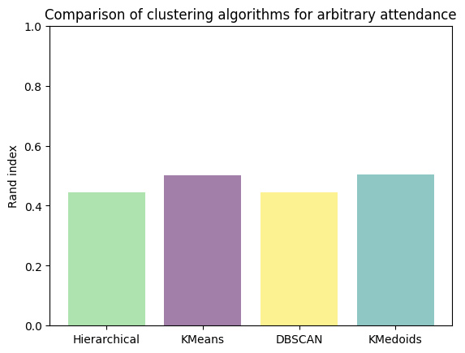

```python
# Comparison of several clustering algorithms
ri = np.zeros((4))
x=[0,1,2,3]

kmedoids = KMedoids(n_clusters=3, random_state=42)
kmeans = KMeans(n_clusters=3, random_state=42)
kmeans.fit(data)
ri[0] = rand_index(targets, agglomerativeClustering(data, 3))
ri[1] = rand_index(targets, kmeans.labels_ )
ri[2] = rand_index(targets, DBSCAN(eps=0.5, min_samples=5).fit(data).labels_)
ri[3] = rand_index(targets, kmedoids.fit_predict(data))
plt.title('Comparison of clustering algorithms for arbitrary attendance')
plt.bar(x, ri, alpha=0.5, ecolor='black', color=['#5ec962','#440154','#fde725','#21918c'])
plt.ylim(0,1)
plt.ylabel('Rand index')
plt.xticks(x, ['Hierarchical', 'KMeans', 'DBSCAN', 'KMedoids'])
plt.show()
```

The clustering method performs less well with arbitrarily value of affluence than the two others. We achieve a performance of approxiamtively 50% and less for each of the clustering techniques, which is relatively low compared to what we obtained in the first method and which stays lower than in the second method

### **DecisionTree ('gini' and 'entropy') and Naive Bayesian**

```python
model_comparison={}
```

```python
scaler = StandardScaler()
X = scaler.fit_transform(data)
Y = df.loc[:, 'Attendance']
```

```python
X_train, X_test, y_train, y_test = train_test_split(X, Y, test_size=0.2, random_state=20, stratify=Y)
```

#### Decision Tree

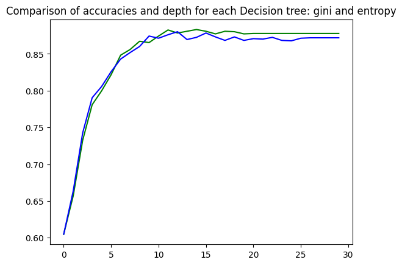

```python
# Plot to test the different depths of the tree
acc_entropy=[]
acc_gini=[]

for i in range(30):
  tree_entropy = DecisionTreeClassifier(max_depth=i+1, random_state = 42, criterion='entropy')
  tree_entropy.fit(X_train, y_train)
  y_pred_entropy = tree_entropy.predict(X_test)
  accuracy_entropy = accuracy_score(y_test, y_pred_entropy)
  acc_entropy.append(accuracy_entropy)

  tree_gini = DecisionTreeClassifier(max_depth=i+1, random_state = 42, criterion='gini')
  tree_gini.fit(X_train, y_train)
  y_pred_gini = tree_gini.predict(X_test)
  accuracy_gini = accuracy_score(y_test, y_pred_gini)
  acc_gini.append(accuracy_gini)

plt.title('Comparison of accuracies and depth for each Decision tree: gini and entropy')
plt.plot(range(30),acc_entropy,color='green')
plt.plot(range(30),acc_gini,color='blue')
```

```python
# Identifying the Best Depth for the Gini Tree
best_accuracy_g=max(acc_gini)
best_depth_g=acc_gini.index(best_accuracy_g)+1
print(f'Deciscion tree with gini maximzed depth: {best_depth_g} with accuracy {best_accuracy_g}')

best_accuracy_a=max(acc_entropy)
best_depth_a=acc_entropy.index(best_accuracy_a)+1
print(f'Deciscion tree with entropy maximzed depth: {best_depth_a} with accuracy {best_accuracy_a}')
```

```
Deciscion tree with gini maximzed depth: 13 with accuracy 0.8800945067926758
Deciscion tree with entropy maximzed depth: 15 with accuracy 0.8830478440637921
```

```python
# Training and evaluation of a decision tree with the Gini criterion
tree_gini = DecisionTreeClassifier(max_depth=best_depth_g, random_state = 42, criterion='gini')
tree_gini.fit(X_train, y_train)
y_pred_gini = tree_gini.predict(X_test)
accuracy_gini = accuracy_score(y_test, y_pred_gini)
conf_matrix_g = confusion_matrix(y_test, y_pred_gini)
classification_rep_g = classification_report(y_test, y_pred_gini)
print("The precision of the tree with gini is: ", accuracy_gini)
print(f"Confusion Matrix:\n{conf_matrix_g}")
print(f"Classification Report:\n{classification_rep_g}")
```

```
The precision of the tree with gini is:  0.8800945067926758
Confusion Matrix:
[[959  57   8]
 [ 62 272  37]
 [  8  31 259]]
Classification Report:
              precision    recall  f1-score   support

           0       0.93      0.94      0.93      1024
           1       0.76      0.73      0.74       371
           2       0.85      0.87      0.86       298

    accuracy                           0.88      1693
   macro avg       0.85      0.85      0.85      1693
weighted avg       0.88      0.88      0.88      1693
```

```python
tree_entropy = DecisionTreeClassifier(max_depth=best_depth_a, random_state = 42, criterion='entropy')
tree_entropy.fit(X_train, y_train)
y_pred_entropy = tree_entropy.predict(X_test)
accuracy_entropy = accuracy_score(y_test, y_pred_entropy)
conf_matrix_e = confusion_matrix(y_test, y_pred_entropy)
classification_rep_e = classification_report(y_test, y_pred_entropy)
print("The precision of the tree with entropy is: ", accuracy_entropy)
print(f"Confusion Matrix:\n{conf_matrix_e}")
print(f"Classification Report:\n{classification_rep_e}")
```

```
The precision of the tree with entropy is:  0.8830478440637921
Confusion Matrix:
[[968  50   6]
 [ 61 259  51]
 [  3  27 268]]
Classification Report:
              precision    recall  f1-score   support

           0       0.94      0.95      0.94      1024
           1       0.77      0.70      0.73       371
           2       0.82      0.90      0.86       298

    accuracy                           0.88      1693
   macro avg       0.84      0.85      0.84      1693
weighted avg       0.88      0.88      0.88      1693
```

```python
model_comparison['DecisionTree']=[r2_score(y_test,y_pred_entropy),mean_squared_error(y_test,y_pred_entropy),(accuracy_entropy)]
```

#### Naiive Bayesian

```python
scaler_STD = StandardScaler()
scaler_Norm = MinMaxScaler()
X_train_STD = scaler_STD.fit_transform(X_train)
X_test_STD = scaler_STD.fit_transform(X_test)
```

```python
model = GaussianNB()
model.fit(X_train_STD, y_train)
y_pred = model.predict(X_test_STD)

accuracy = accuracy_score(y_test, y_pred)
conf_matrix = confusion_matrix(y_test, y_pred)
classification_rep = classification_report(y_test, y_pred)

print(f"Accuracy: {accuracy}")
print(f"Confusion Matrix:\n{conf_matrix}")
print(f"Classification Report:\n{classification_rep}")
```

```
Accuracy: 0.5664500886001181
Confusion Matrix:
[[612 412   0]
 [ 24 347   0]
 [  7 291   0]]
Classification Report:
              precision    recall  f1-score   support

           0       0.95      0.60      0.73      1024
           1       0.33      0.94      0.49       371
           2       0.00      0.00      0.00       298

    accuracy                           0.57      1693
   macro avg       0.43      0.51      0.41      1693
weighted avg       0.65      0.57      0.55      1693
```

```python
# Grid Search for Naive Bayesian
param_grid_nb = {
    'var_smoothing': [1e-9, 1e-8, 1e-7, 1e-6, 1e-5]
}

nb_model = GaussianNB()
grid_search_nb = GridSearchCV(nb_model, param_grid_nb, cv=5, scoring='accuracy')
grid_search_nb.fit(X_train_STD, y_train)

best_params_nb = grid_search_nb.best_params_
best_accuracy_nb = grid_search_nb.best_score_

final_nb_model = grid_search_nb.best_estimator_
final_nb_model.fit(X_train, y_train)
y_pred = final_nb_model.predict(X_test)
model_comparison['Naive Bayesian Regression']=[r2_score(y_test,y_pred),mean_squared_error(y_test,y_pred),(best_accuracy_nb)]
```

#### Random Forest

```python
ML_pipeline = make_pipeline(StandardScaler(), PCA(n_components=2), RandomForestClassifier(criterion='entropy', n_estimators=200, max_depth=20, min_samples_split=2, random_state=42))
ML_pipeline.fit(X_train, y_train)
y_pred = ML_pipeline.predict(X_test)
test_acc = ML_pipeline.score(X_test, y_test)
conf_matrix = confusion_matrix(y_test, y_pred)
classification_rep = classification_report(y_test, y_pred)
print(f'Test accuracy: {test_acc:.3f}')
print(f"Confusion Matrix:\n{conf_matrix}")
print(f"Classification Report:\n{classification_rep}")
```

```
Test accuracy: 0.715
Confusion Matrix:
[[925  67  32]
 [132 126 113]
 [ 43  95 160]]
Classification Report:
              precision    recall  f1-score   support

           0       0.84      0.90      0.87      1024
           1       0.44      0.34      0.38       371
           2       0.52      0.54      0.53       298

    accuracy                           0.72      1693
   macro avg       0.60      0.59      0.59      1693
weighted avg       0.70      0.72      0.70      1693
```

```python
# Finding the best hyperparameters for the RandomForest model
from sklearn.model_selection import GridSearchCV

param_grid = {
    'randomforestclassifier__n_estimators': [50,100, 200],
    'randomforestclassifier__max_depth': [5,10, 15],
    'randomforestclassifier__min_samples_split': [2,5,10]
}

grid_search = GridSearchCV(estimator=ML_pipeline, param_grid=param_grid, cv=5, verbose=1, n_jobs=-1)
grid_search.fit(X_train, y_train)
best_params = grid_search.best_params_
print("Best hyperparameters: ", best_params)
best_score = grid_search.best_score_
print("Best score: ", best_score)
best_model = grid_search.best_estimator_
y_pred = best_model.predict(X_test)
model_comparison['Random Forest']=[r2_score(y_test,y_pred),mean_squared_error(y_test,y_pred),(best_score)]
```

[output not shown]

```
Fitting 5 folds for each of 27 candidates, totalling 135 fits
```

Now, we analyse for an abitrary 'attendance' the results of the different algorithms

```python
Model_com_df=pd.DataFrame(model_comparison).T
Model_com_df.columns=['R-Square','MSE','Accuracy']
Model_com_df=Model_com_df.sort_values(by='Accuracy',ascending=False)
Model_com_df.style.format("{:.2%}").background_gradient(cmap='viridis')
```

[output not shown]

Overall, the results are not as good as in the previous method, but they still compete with those of the first method.

## Conclusion

To conclude our machine learning work on our dataset:

For our model, we choose to use the algorithm with the highest accuracy, which is DecisionTree with binary attendance. However, it is important to consider that the information provided by the binary 'attendance' is less detailed than that provided by the 4 classes. With binary, we can determine if the attendance is high or low, while with 4 classes, there are more nuances, making the predicted information more precise.

Both the Naive Bayesian and Random Forest remain viable algorithms in our context.

# GENERAL CONCLUSION

Today, we are able to provide the following information:

Giving the climate measures of a day, the hour and the date, we can say, using DecisionTree with 90% of accuracy, if the attendance of the rented bike system in Seoul is low or high. With more than 80% of accuracy and the same algorithm, we can even detail the attendance of the rent with 4 degrees based on the stats of rented bike number that we have.

# **API**

```python
def Attendance(model, Hour, Temperature, Humidity, Wind_speed, Visibility, Radiation, Rainfall, Snowfall, Day, Month, Week_day_Friday, Week_day_Monday, Week_day_Saturday, Week_day_Sunday, Week_day_Thursday, Week_day_Tuesday, Week_day_Wednesday, Holiday):
    def seasons(M):
      if M >= 1 & M < 3 :
         Seasons_Autumn = 0
         Seasons_Spring = 0
         Seasons_Summer = 0
         Seasons_Winter = 1
         return Seasons_Autumn, Seasons_Spring, Seasons_Summer, Seasons_Winter
      if M >= 3 & M < 6 :
         Seasons_Autumn = 0
         Seasons_Spring = 1
         Seasons_Summer = 0
         Seasons_Winter = 0
         return Seasons_Autumn, Seasons_Spring, Seasons_Summer, Seasons_Winter
      if M >= 6 & M < 9 :
         Seasons_Autumn = 0
         Seasons_Spring = 0
         Seasons_Summer = 1
         Seasons_Winter = 0
         return Seasons_Autumn, Seasons_Spring, Seasons_Summer, Seasons_Winter
      if M >= 9 & M <= 12 :
         Seasons_Autumn = 1
         Seasons_Spring = 0
         Seasons_Summer = 0
         Seasons_Winter = 0
         return Seasons_Autumn, Seasons_Spring, Seasons_Summer, Seasons_Winter

    def moment_day(hour):
        if 0<=hour<6:
          Moment_day_Afternoon = 0
          Moment_day_Evening = 0
          Moment_day_Morning = 0
          Moment_day_Night = 1
          return Moment_day_Afternoon, Moment_day_Evening, Moment_day_Morning, Moment_day_Night
        if 6<=hour<12:
          Moment_day_Afternoon = 0
          Moment_day_Evening = 0
          Moment_day_Morning = 1
          Moment_day_Night = 0
          return Moment_day_Afternoon, Moment_day_Evening, Moment_day_Morning, Moment_day_Night
        if 12<=hour<=18:
          Moment_day_Afternoon = 1
          Moment_day_Evening = 0
          Moment_day_Morning = 0
          Moment_day_Night = 0
          return Moment_day_Afternoon, Moment_day_Evening, Moment_day_Morning, Moment_day_Night
        if 18<hour<=23:
          Moment_day_Afternoon = 0
          Moment_day_Evening = 1
          Moment_day_Morning = 0
          Moment_day_Night = 0
          return Moment_day_Afternoon, Moment_day_Evening, Moment_day_Morning, Moment_day_Night


    Seasons_Autumn, Seasons_Spring, Seasons_Summer,Seasons_Winter = seasons(Month)
    Moment_day_Afternoon, Moment_day_Evening, Moment_day_Morning, Moment_day_Night = moment_day(Hour)

    x = np.array([Hour, Temperature, Humidity, Wind_speed, Visibility, Radiation, Rainfall, Snowfall, Day, Month, Seasons_Autumn, Seasons_Spring, Seasons_Summer,Seasons_Winter, Moment_day_Afternoon, Moment_day_Evening, Moment_day_Morning, Moment_day_Night, Week_day_Friday, Week_day_Monday, Week_day_Saturday, Week_day_Sunday, Week_day_Thursday, Week_day_Tuesday, Week_day_Wednesday, Holiday]).reshape(1, -1)
    model.fit(X_train, y_train)
    prediction = model.predict(x)
    probability = model.predict_proba(x)
    formatted_probabilities = [[round(prob, 2) for prob in class_probs] for class_probs in probability]
    print("Prediction:", prediction)
    print("Probabilities:", probability)

Attendance(tree_gini_BS, 14, 15, 37, 2.2, 2000, 0.0, 0.0, 0.0, 11, 11, 0, 1, 0, 0, 0, 0, 0, 1)
```